# WFT-Vermogen Samenvatting

SN de Koning

7 juni 2016

## 1. Algemeen.

*(pg 3-6)*

#### 1.1. De Drie Pijlers.

1. *Basisvoorzieningen* -> verzorgd door de overheid.
2. *Aanvullende pensioenen* -> verzorgd door de werkgever.
3. *Privévoorzieningen* -> verzorgd door de consument.

#### 1.1.1. Basis of overheidsvoorzieningen.

Sociale regelgeving te verdelen in:

1. *Sociale verzekeringen*
   1. volksverzekeringen (voor iedereen, e.g. `AOW`, `Anw`, `Wlz`).
   2. werknemersverzekeringen (voor werknemers, e.g. `WIA`, `WW`).
2. *Sociale voorzieningen* (aanvulling op sociale verzekeringen, e.g. Participatiewet, Toeslagenwet).

Voorzien slechts in minimale levensbehoefte.

#### 1.1.2. Pensioen

1. *Werknemerspensioen*
   - e.g. ouderdoms-, nabestaanden- en arbeidongeschiktheidspensioen.
   - houd rekening met voorzieningen vanuit pijler 1.
   - verplicht via cao of aansluiting via ondernemings- of bedrijfstakpensioenfonds.
   - geen algemene pensioenplicht in Nederland.
2. *Oudedagsvoorziening zelfstandig ondernemers*
   - regelen via pijler 3.
   - geen verplichting, m.u.v. bepaalde groepen ondernemers zoals huisartsen.
   - aparte fiscale regelingen.
3. *Pensioen werknemer-grootaandeelhouder*
   - “Gewone werknemer”
   - valt niet onder de Pensioenwet
   - hoeft het pensioen niet onder te brengen bij speciale verzekeraar, maar kan dit doen via eigen beheer, of een aparte pensioen-BV.
   - directeur-grootaandeelhouder, `DGA`, is een persoon met >= 10% van de aandelen van BV.

#### 1.1.3. Privevoorzieningen.

Elke voorziening dat een klant al dan niet in aanvulling op de voorgenoemde kan treffen. Geheel vrijwillig, en hoeven geen direct verband met de verrichte arbeid te hebben.

## 2. Levensverzekeringen algemeen.

*(pg 7-9)*

#### 2.1. Definitie levensverzekering.

> een overeenkomst van verzekering tot het doen van geldelijke uitkeringen of een uitkering in natura in verband met het leven of de dood van de mens, met dien verstande dat overeenkomsten van ongevallenverzekering niet als overeenkomsten van levensverzekering worden beschouwd.
1. *een verzekering*
   - kansovereenkomst, i.e. onzeker voorval.
2. *uitkering in geld of natura*
   - in natura denk aan uitvaart.
3. *houdt verband met het leven of de dood van de mens*
   - Uitkering bij leven/sterfte/gecombineerd.
   - Levensverzekering is sommenverzekering.
4. *is geen ongevallenverzekering*

#### 2.2. Betrokken partijen bij een levensverzekering.

- de verzekeraar
- de verzekeringnemer
- de premieverschuldigde
- de verzekerde(n)
- de begunstigde(n)

#### 2.2.1

de volgorde in standaardbegunstiging is:

1. de verzekeringnemer
2. de echtgenoot/geregistreerde partner
3. kinderen
4. overige erfgenamen

**NB.** Samenwonende partner valt buiten de kring standaardbegunstigden. Oplossingen zijn deze medeverzekeringnemer te maken, of de tweede begunstigde te wijzigen in de partner.

#### 2.3. Redenen voor een levensverzekering.

Het dekken van de volgende risico’s:

1. Risico van lang leven.
   - langer leven dan financieel gepland.
2. Risico van kort leven (overlijden).

De vier redenen voor het afsluiten van een levensverzekering:

1. *Schuldaflossing*
   - vaak afgeslotenin combinatie met hypothecair krediet.
   - uitkering bij eindtermijn om krediet ineens af te lossen.
2. *De verzorging van de nabestaanden*
   - financiële zekerheid voor nabestaanden.
   - periodieke uitkering; voor gehele of gedeeltelijke vervanging van inkomen.
   - uitkering ineens; voor afbetaling openstaande leningen, uitvaart, of om enige tijd van te leven.
3. *Inkomen voor de oude dag*
   - periodieke uitkering na bereiken bepaalde leeftijd. e.g. pensioen (via werkgever), lijfrente (prive).
4. *Sparen voor toekomstige lasten.*
   - e.g. studieverzekering voor kind.

## 3. Inhoud van de levensverzekeringsovereenkomst.

*(pg 11-25)*

#### 3.1. Het afsluiten van een levensverzekering.

In het onderstaande schema is aangegeven hoe het proces van afsluiting verloopt:

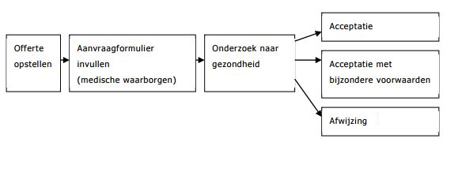

1. *Offerte*
   - na de intake waaruit de wensen van de klant naar voren worden gehaald stelt de adviseur offertes van de verschillende opties op.
2. *Aanvraagformulier en eventuele medische waarborgen*
   - niet van belang bij uitkering bij leven op een bepaalde datum.
   - types medische waarborgen:
     - gezondheidsverklaring (vragenlijst)
     - huisartsenkeuring (bij aanvangsrisico >250k ,ookwel vragengrens)
     - internistenkeuring (bij aanvangsrisico >500k)
   - het aanvangsrisico is de schade voor de verzekeraar bij het overlijden of AO raken van de verzekerde direct na afsluiting. Dit heeft geen gevolg voor de premie, wel bij een betaalde koopsom; dit vermindert het aanvangsrisico.
   - sinds 2012 veranderingen omtrent navraag doen ziektegeschiedenis van familieleden.
     - *verzekerd bedrag onder de vragengrens*: GEEN vragen over erfelijke aandoeningen binnen de familie, of dat verzekerde drager is. Als verzekerde wel ziek is, is hij verplicht dit te melden.
     - *verzekerd bedrag boven de vragengrens*: WEL vragen over erfelijke aandoeningen binnen de familie, indien aanwezig en is de verzekerde onderzocht, dient hij de uitslag te melden. De verzekeraar kan NIET verplichten tot het ondergaan van een onderzoek.
   - indien de verzekerde een bestaande levensverzekering wil aanpassen en het risico wordt hierdoor groter voor de verzekeraar, mag deze opnieuw om gezondheidswaarborgen vragen.
   - bij een verzekering die uitkeert bij leven zal een verzekeraar vragen om medische waarborgen als de verzekerde eerder wil uitkeren. Dit ter voorkoming dat iedereen die ongezond is, eerder de verzekering zal willen afkopen.
   - Wet op de Medische Keuringen, `WMK`, geld sinds 01-01-1998.
     - ter bescherming van mensen met gezondheidsproblemen zodat zij een arbeidscontract aan kunnen gaan en verzekeringen tegen “normale” premies en voorwaarden kunnen afsluiten.
     - de wet stelt dat alleen keuringen mogen worden gedaan indien de bewuste functie bijzondere gezondheidseisen stelt voor het uitoefenen van de werkzaamheden.
     - werknemers mogen NIET gekeurd worden voor verzekeringen die zij via hun werkgever kunnen afsluiten. Denk hierbij aan pensioenverzekeringen, aanvullende arbeidsongeschiktheidsverzekeringen en verzekeringen die door de werkgever worden afgesloten om het financiële risico van de werknemer bij ziekte en arbeidsongeschiktheid te beperken.
     - uitzonderingen op het hierbovenstaande zijn: pensioen- of arbeidongeschiktheidsverzekeringen ‘DGA’, bijzondere beroepen (e.g. piloot of stratenmaker) of indien een werknemer in eerste instantie niet wil meedoen met de collectiviteiten via een werkgever maar later toch wil deelnemen (spijtoptanten).
   - Wet op de Geneeskundige Behandelingsovereenkomst, `WGBO`. Deze wet beschrijft de rechten en plichten van cliënten in de zorg. In het geval van onderzoeken of behandelen in medische context, is deze wet van kracht. Het gaat dan om de volgende rechten en plichten voor de patiënt:
     - recht op informatie over de medische situatie
     - toestemming voor een medische behandeling
     - inzage in het medisch dossier
     - recht op privacy en geheimhouding van medische gegevens (het beroepsgeheim)
     - recht op vrije artsenkeuze
     - vertegenwoordiging van patiënten die niet zelf kunnen beslissen.
     - de patiënt dient de zorgverlener goed, eerlijk en volledig op de hoogte te stellen van de problematiek.
     - de patiënt dient zo veel mogelijk meewerken en adviezen opvolgen
     - bij uitzondering mag een arts zonder toestemming een medische ingreep doen, ter voorkoming van sterfte of het verkrijgen van een ernstige handicap. Dit mag ook onder dwang.
   - voorlopige dekking houdt in dat de verzekerde al verzekerd is voordat de verzekering daadwerkelijk is afgesloten. Na verdere beoordeling kan de verzekering nog steeds worden afgewezen of tegen beperkende voorwaarden aan te bieden. Bij wijzigingen van de gezondheid in deze periode dient de verzekerde deze bij de verzekeraar door te geven. Voor deze periode geldt:
     - dekking voor het risico van overlijden.
     - voor een beperkte termijn van max. 30 dagen.
     - tot een max. verzekerd bedrag van EUR 160.000.
3. *Onderzoek naar de gezondheid*
   - a.d.h.v. de gezondheidsverklaringen of medisch onderzoek kan de verzekeraar aanvullende gegevens opvragen bij de huisarts of internist. Hiervoor is toestemming van de verzekerde nodig.
   - de medisch adviseur van de verzekeraar beoordeelt de gegevens en leidt tot:
     - een acceptatie
     - een acceptatie met bijzondere voorwaarden, deze kunnen zijn:
       - een lager verzekerd kapitaal
       - een hogere premie
       - een kortere looptijd van de verzekering
       - een wachttijd (carentztijd)
       - een andere verzekeringsvorm
       - een uitsluiting (tijdelijk of blijvend)
       - een combinatie van de voorgenoemde voorwaarden.
     - een afwijzing.
   - de carentztijd is de wachtijd in de dekking als de kandidaat-verzekerde een risico loopt waarvan vooraf al bekend is dat deze zal verdwijnen.
     - Alleen mogelijk bij verzekeringen die niet via een werkgever worden afgesloten. Dit is sinds 01-01-2010. Zie het Van Leeuwen-convenant ter verbetering van de arbeidsparticipatie en arbeidsmobiliteit van gehandicapte of chronisch zieke werknemers.
   - Levensverzekeraar De Hoop is een verzekeraar voor mensen van wie bekend is dat acceptatie bij gewone verzekeraars lastig gaat worden, of wie al meerdere afwijzingen hebben gehad.
     - De hoop is een herverzekeraar, de verzekering loopt bij de verzekeraar waarbij de aanvraag is gedaan, en deze herverzekert het bij De Hoop. De klant betaald wel een hogere premie vanwege het hogere risico.
4. *De verzekering komt tot stand*
   - deze komt pas tot stand na acceptatie van de verzekeraar, zelfs in het geval van voorlopige dekking
5. *De afkoelingsperiode*
   - bij een verzekering met een looptijd van langer dan zes maanden, geldt er een opzegtermijn. d.w.z. de verzekernemer kan minimaal dertig dagen na tot het tot stand komen van de verzekering deze zonder opgaaf van reden opzeggen. Dit kan uitsluitend schriftelijk.
6. *De polis*
   - het bewijs van bestaan van de verzekering.
   - hier moet in ieder geval de volgende zaken op staan:
     - de ingangsdatum
     - de naam van de verzekerde
     - de naam van wie het leven is verzekerd
     - de tijdsperiode waarin het risico is verzekerd
     - de verzekerde som
     - de verschuldigde premie
     - de begungstigde.
   - hiernaast ontvangt de verzekeringsnemer:
     - de algemene polisvoorwaarden
     - clausulebladen
     - polisvoorwaarden voor aanvullende dekkingen.
   - bij verlies van de originele polis is het meestal mogelijk een duplicaatpolis aan te vragen. Hierbij dient de verzekernemer een akte van vrijwaring te ondertekenen dat het origineel verloren is gegaan en dat hij de maatschappij vrijwaart tegen eventuele aanspraken die tegenover haar op grond van de originele polis worden ingesteld.
   - Het moment van het tot stand komen van de polis en het risico-ingang zijn niet altijd hetzelfde. Afwijkingen zijn te vinden in de polisvoorwaarden.

#### 3.2 De rechten van de verzekeringnemer

De belangrijkste rechten van de verzekeringnemer zijn:

1. *aanwijzing of wijzingen van de begunstiging*
   - indien er niets is geregeld is de volgende standaardbegunstiging van toepassing:
     1. verzekeringnemer
     2. echtgenoot/geregistreerd partner van de verzekeringnemer
     3. kinderen van de verzekeringnemer
     4. erfgenamen van de verzekeringnemer
   - er zijn twee vormen van begunstiging:
     1. *de niet-aanvaarde begunstiging*, standaard, de verzekeringsnemer behoud ten alle tijden het recht iemand anders aan te wijzen als begunstigde.
     2. *de aanvaarde begunstiging*, de begunstigde heeft schriftelijk expliciet de begunstiging aanvaard. De verzekeringsnemer kan geen handelingen meer uitvoeren die ten nadeel van de begunstigde zijn. Wijzigingen zijn alleen mogelijk met toestemming van de begunstigde.
2. *afkoop*
   - uitbetaling van de waarde van de verzekering. Hierna is de verzekering beëindigd. Dit kan fiscale gevolgen hebben.
   - de volgende voorwaarden zijn noodzakelijk voor afkoping:
     1. er is een recht op een stellige (zekere) uitkering
     2. de verzekering heeft een bepaalde waarde.
3. *niet meer betalen van de premie*
   - de levensverzekering is een eenzijdige overeenkomst, d.w.z. er is geen sprake van premiebetalingsverplichting. Bij achterwegelating van premiebetaling kunnen de volgende consequenties hebben:
     - premievrij voortzetten
       - premiebetaler stopt premiebetaling.
       - afkoopwaarde geld als koopsom voor gewijzigde verzekering.
       - eindkapitaal wordt herrekend naar nieuwe koopsom.
       - bij beleggingsverzekeringen worden er nog wel kosten uit de waarde onttrokken.
       - gevolg door rendement is de premievrijwe waarde hoger dan de afkoopwaarde.
     - automatisch voortzetten
       - premiebetaler stopt premiebetaling.
       - verzekering wordt in haar oorspronkelijke vorm en voor het oorspronkelijk verzekerde voortgezet.
       - onbetaalde premies worden door de verzekeraar als een lening aan de verzekeringnemer beschouwd, welke op één van de volgende manieren kunnen worden verrekend:
         - zodra de som van de onbetaalde premies plus interest en kosten hoger is dan de afkoopwaarde, vervalt de polis zonder waarde.
         - bij in leven zijn op de einddatum: de onbetaalde premies plus interest en kosten komen in mindering op het verzekerde kapitaal bij leven.
         - bij overlijden van de verzekerde voor de einddatum van de verzekering: de onbetaalde premies plus interest en kosten komen in mindering op het verzekerde kapitaal bij overlijden.
     - onverminderd voortzetten
       - dit gebeurt bij gemengde verzekeringen.
       - premiebetaler stopt premiebetaling.
       - het overlijdensrisicokapitaal blijft in stand, zolang er voldoende kapitaal in de polis zit om de premie uit te onttrekken.
       - als er op de einddatum nog een waarde in de polis zit, wordt deze uitgekeerd aan de begunstigde.
     - de verzekering afkopen, of als deze geen waarde heeft, laten vervallen. Dit heet royeren.
   - in het geval van aanvaarde begunstiging of verpanding zal de begunstigde of de pandhouder op de hoogte worden gesteld. Hiernaast kunnen er fiscale gevolgen zijn voor de behandeling van de polis.
4. *belening*
   - het recht van de verzekeringsnemer om geld te lenen bij de verzekeraar.
   - een rentedragend voorschot op toekomstige uitkering.
   - op de einddatum brengt de verzekeraar het geleende bedrag plus rente in mindering op de uitkering.
   - kan fiscale gevolgen hebben voor de behandeling van de verzekering.
   - het te belenen bedrag is lager dan de aanwezige afkoopwaarde.
   - bij beleggingsverzekeringen zijn er maar beperkte beleningsmogelijkheden, of zelfs zijn deze volledig uitgesloten.
5. *conversie*
   - het omzetten van de verzekeringsvorm naar een andere vorm door de verzekeringsnemer.
   - in de regel alleen mogelijk als er waarde in de polis aanwezig is.
   - bij omzetting van een verzekering met alleen een uitkering naar leven naar een uitkering bij overlijden zal de verzekeraar wel om een gezondheidsverklaring vragen.
   - dit is een indirect recht, omdat deze niet expliciet opgenomen in de wet is.

#### Verzwijging, ofwel de mededelingsplicht van de verzekeringnemer

Het is verplicht voor de kandidaat-verzekeringsnemer alle informatie te verstrekken die relevant is voor de verzekeringsaanvraag. Hierbij geld dat de verzekeringsnemer geen informatie moet geven waar niet om wordt gevraagd. Moedwillige misleiding is hierbij een uitzondering.

Voor de mededelingsplicht zijn drie vereisten:

1. *kennisvereiste*
   - de verzekeringsnemer is verplicht alle informatie te geven die hij kent, of behoort te kennen.
2. *kenbaarheidsvereiste*
   - de informatie moet betrekking hebben op de beslissing tot acceptatie van de verzekeraar. De kandidaat weet of behoort te begrijpen dat deze van invloed is op deze beslissing.
3. *verschoonbaarheidsvereiste*
   - de mededelingsplicht geldt niet als deze betrekking heeft op informaite die de verzekeraar al kent, of behoort te kennen.
   - **NB.** een verzekeraar mag nooit een aanvraagformulier en gezondheidsverklaring van een andere verzekering gebruiken voor informatie in geval van uitkering.

De consequenties van het niet voldoen aan de mededelingsplicht is afhankelijk van het moment van ontdekking.

1. *In het geval van ontdekking tijdens de looptijd*
   - dient bij ontdekking binnen twee maanden een melding te maken bij de verzekeringsnemer. Er zijn dan twee mogelijkheden.
     1. aanpassen van de verzekering. Dit geldt als de verzekeraar de verzekering onder andere voorwaarden wel had geaccepteerd. De verzekernemer heeft twee maanden bedenktijd, indien niet akkoord, komt de verzekering te vervallen.
     2. opzegging van de verzekering. Ookwel het opzeggingsrecht. Dit geldt alleen als de verzekeraar de verzekering niet geaccepteerd zou hebben. De verzekeringsnemer heeft wel recht op de afkoopwaarde van de verzekering, als de verzekeraar gebruik maakt van dit opzeggingsrecht. De afkoopwaarde is een dag voor de beëindiging van de overeenkomst.
2. *In het geval van ontdekking op het moment van uitkering*
   - de verzekeraar keert volledig uit.
     - als de onjuiste informatie niet van belang is voor het risico dat verzekerd is.
     - dit heet het causaliteitsbeginsel.
   - de verzekeraar keert gedeeltelijk uit.
     - er is een causaal verband tussen de onjuiste informatie en het verzekerde risico.
     - de uitkering wordt evenredig verlaagd tot het niveau dat overeenkomt als wel alle informatie was verstrekt.
     - dit heet het proportionaliteitsbeginsel.
   - de verzekeraar keert helemaal niet uit.
     - de begunstigde ontvangt de afkoopwaarde van de verzekering.
     - bij opzettelijk misleiden keert de verzekeraar niets uit.

#### 3.3 Uitsluitingsclausules

1. *Overlijden ten gevolge van zelfdoding*
   - volgens de wet komt de verzekering te vervallen indien iemand met een levenesverzekering zelfmoord pleegt.
   - dit is geen dwingent recht, meestal passen verzekeraars een carenzperiode van 2 jaren toe.
   - uitsluiting op het bovengenoemde in het geval van euthanasie, op voorwaarde dat dit binnen de wettelijke regelgeving van toegestane euthanasie valt.
2. *Atoomkernreacties en/of radioactiviteit*
   - m.u.v. medische behandelingen van de verzekerde.
3. *Overlijden ten gevolge van een misdrijf*
   - een misdrijf door de begunstigde
   - opzet of grove schuld door de verzekerde, een begunstigde, of de verzekeringsnemer
   - het deelnemen aan of plegen van een misdrijf door de verzekerde of een poging daartoe.
     - niet bij elke verzekeraar van toepassing.
   - afwijkingen hiervan kunnen gevonden worden in de polisvoorwaarden.
4. *Oorlogsdekking voor militairen*
   - Geen dekking bij:
     - overlijden ten tijde van een vliegtocht
     - overlijden als direct gevolg van gevechtshandelingen tijdens uitzending als militair of als ambtenaar van Defensie.
       - uitzondering voor verzekering voor aflossing van een woningsfinanciering met een max. van EUR 400.000
     - overlijden van militairen in enige niet-Nederlandse krijgs- of gewapende dienst.

#### 3.4 Aanvullende dekkingen.

Verzekeringen die ook onder levensverzekeringen vallen zijn bijvoorbeeld:

- Premievrijstelling bij arbeidsongeschiktheid.
  - het recht niet meer verschuldigd te zijn van de premie bij arbeidsongeschiktheid van de verzekerde, waarbij de dekking ongewijzigd blijft.
  - dit kan alleen in het geval waarbij premiebetaler en verzekerde dezelfde persoon zijn.
  - ook een gedeeltlijke vorm is mogelijk waarbij een gedeelte van de premie niet meer hoeft betaald te worden, afhankelijk van de mate van arbeidsongeschiktheid.
- Arbeidsongeschiktheidsrente.
  - een periodieke uitkering in het geval dat de verzekerde arbeidsongeschikt is.
  - ter voorkoming van inkomensterugval door arbeidsongeschiktheid.
- Ongevallenverzekering.
  - de begunstigde ontvangt een verhoogde uitkering als de verzekerde door een ongeval overlijdt.

#### 3.5 Clausules

Specifieke bepalingen die niet een logisch onderdeel vormen vna de algemene polisvoorwaarden worden in clausules opgenomen.  
De volgende clausules zijn het meeste voorkomende:

- verpandingsclausule
  - de verzekeringnemer heeft de uit de polis voortvloeiende rechten overgedragen aan een geldverstrekker.
  - voor een hypothecair of consumptief krediet waarbij de polis onderpand is.
  - er dient een pandakte te worden opgemaakt
  - in de verpandingsclausule dienen de gegevens van de geldverstrekker opgenomen te worden, eveneens als het bedrag van verpanding als deze anders is dan het gehele kapitaal.
- optieclausule
  - het recht van de verzekeringnemer om het verzekerde kapitaal periodiek, te verhogen met een bepaald percentage zonder dag er aanvullende medische waarborgen worden gevraagd.
- indexclausule
  - maakt het mogelijk het verzekerde kapitaal jaarlijks te verhogen zonder medische waarborgen.
  - gekoppeld aan een objectieve parameter, e.g. inflatie.
- kapitaalverzekering eigen woning, `KEW`
  - let op de datum. Fiscale gevolgen voor polissen bestaande op voor 31-12-2012 met de clausule voor 01-04-2013 of op een polis afgesloten voor 01-04-2013, waarbij er op 31-12-2012 wel een eigen woning en eigenwoningschuld aanwezig was.
  - Kan sinds 01-01-2013 niet meer afgesloten worden.
- verzorgersclausule
  - voor kapitaalverzekeringen waarbij de uitkering bestemd is voor een persoon die verzorgd wordt door de verzekeringsnemer.
  - de premiebetaling wordt overgenomen als de verzekeringnemer komt te overlijden.
  - medische waarborgen worden gevraagd van de verzekeringnemer.
  - e.g. bij studieverzekeringen, ouder-kind.
- verbindingsclausule
  - waarbij twee polissen aan elkaar worden gekoppeld zodat ze voor de kosten worden gezien als 1 polis
  - e.g. bij fiscale voortzettng van polissen.
- en bloc-clausule
  - stelt de verzekeraar in staat de voorwaarden eenzijdig te wijzigen.
  - geld voor alle soortgelijke polissen die bij de maatschappij lopen. Nooit voor een individuele polis.

#### 3.6 Expiraties

Expiratie van een verzekering betekent tot uitkering komen.

1. *Uitkeringen bij leven*
   - Verzekeraars sturen doorgaans bij het zicht van de expiratiedatum een brief naar de verzekeraar voor:
     - kijken of de begunstiging gewijzigd moet worden
     - op welke manier hij de uitkering wil krijgen.
     - welke stukken benodigd zijn om de uitkering te kunnen voldoen, welke meestal zijn:
       - *Attestatie de vita* = Het bewijs van in leven te zijn. Dit document valt te verkrijgen bij het gemeentehuis. Bij periodieke uitkering kan de verzekeraar dit periodiek vragen.
       - *Originele Polis*
2. *Uitkering bij overlijden*
   - hierbij worden de volgende stukken gevraagd:
     - *verklarig van erfrecht* = door de notaris verklaart wie de huwelijkspartner, de kinderen en de erfgenamen van de overleden verzekerde zijn.
       - bij een lage uitkering is dit document niet verplicht.
     - *originele polis*
   - **NB.** De uitkering is een zelfstandig recht, d.w.z. valt niet in het nalatenschap. De verzekeringsuitkering gebeurt ook niet via de verdeling van het testament of wettelijk erfrecht.
   - Op de verzekeraar rust niet de verplichting om de uitkering te gaan brengen bij de genoemde begunstigden. Het gaat hier om een haalschuld, als de begunstigde zich niet meldt, reserveert de verzekeraar het geld renteloos.

## 4 Berekeningsmethodiek bij levensverzekeringen.

*(pg 27-34)*

#### 4.1 Grondslagen van een levensverzekeringspremie

De vergoeding van een verzekering gebeurt periodiek (premie) of eenmalig (koopsom). De hoogte van de premie of koopsom wordt bepaald door de volgende drie grondslagen:

1. *kosten*. De kosten die de verzekeraar maakt bij het afsluiten en beheren van de levensverzekering en deze in rekening brengt bij de klant.
   - Eerste kosten.
     - de kosten die gemaakt worden bij het verstrekken van offertes.
     - de administratieve kosten voor het opmaken van de polis.
     - **NB.** per 01-01-2013 geld er een provisieverbod voor verzekeraars.
   - Doorlopende kosten.
     - de beheerkosten van de beleggingsfondsen waarin belegd wordt.
     - de administratiekosten
     - de kosten voor het versturen van waardeoverzichten naar klanten.
2. *interest*. De rente die de verzekeringnemer ontvangt over de ingelegde koopsom of premie
   - gedurende de loop van een verzekering kan de verzekeraar een rendement ontvangen op de koopsom of premie van een klant.
   - van dit rendement vergoed de verzekeraar een deel van de premie- of koopsominterest terug aan de klant.
     - bij verzekeringen met een uitkering bij leven heet dit de spaarpremie of de investeringspremie.
   - hoe hoger de interest vergoed door de verzekeraar, hoe lager de premie of koopsom voor een bepaald verzekerd bedrag.
   - over de interest vangt de klant zelf ook weer interest, dus er is sprake van samengesteld rendement.
   - Als bekend is hoe hoog een uitkering op een bepaald moment moet zijn, is het mogeljk om te berekenen hoe hoog de initiële inleg (de koopsom), moet zijn.
     - de formule hiervoor is
       $$u / ((100 + r)/100)^l$$
       waarbij $u$ = uitkering, $r$ = rente en $l$ = looptijd
3. *risico*. Het risico op overlijden of het in leven zijn van de verzekerde waardoor er een uitkering volgt. Deze grondslag staat ook wel bekend als sterfte.
   - de verzekeraar bepaalt het risico a.d.h.v. sterftekansen, welke gehaald worden uit het door het CBS 5-jaarlijkse geplubliceerde sterfte- of overlevingstafel.
     - verzekeraars met de meest recente sterftetafels hanteren doorgaans lagere premies, dit vanwege de toenemende gemiddelde leeftijd.
   - de invloed van de sterftekans op de hoogte van de premie of koopsom is afhankelijk van het soort verzekering.
     - uitkering bij leven. Hoe jonger de verzekeringsnemer, hoe groter de kans voor de verzekeraar dat zij moet uitkeren. Dus hogere premie voor jongere mensen.
     - uitkering bij sterfte. Hoe ouder de verzekeringsnemer, des te hoger de sterftekans, dus hoe hoger de kans dat de verzekeraar moet uitkeren. Dus hogere premie voor oudere mensen.
   - soort premie.
     - eenjarige risicopremie.
       - de premie stijgt hierbij jaarlijks, doordat de premie elk jaar opnieuw wordt bepaald a.d.h.v. de leeftijd van de verzekerde.
     - doorsnederisicopremie.
       - de premie blijft over de looptijd gelijk, er wordt een gemiddelde premie berekend.
     - zie figuur.

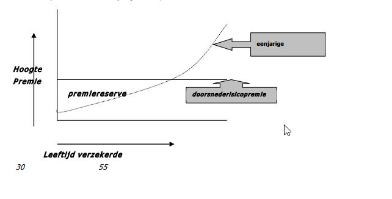

   - winst of verliesrisicopremie.
     - als meer mensen overlijden dan verwacht is er sprake van oversterfte.
     - als minder mensen overlijden dan verwacht is er sprake van ondersterfte.
     - als de verzekeraar winst maakt op de risicopremie is er sprake van sterftewinst.
     - als de verzekeraar verlies maakt op de risicopremie is er sprake van sterfteverlies.
     - zie onderstaand figuur voor schematisch weergegeven:

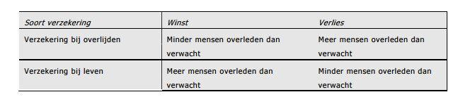

   - rokers-/niet-rokerstarief.
     - sommige verzekeraars brengen een hogere risicopremie in rekening als de verzekerde rookt, of enige tijd (doorgaans langer dan 2 jaar) geleden heeft gerookt.
   - onafhankelijkheid van geslacht.
     - sinds 21-12-2012 mogen verzekeraars voor het vastellen van de hoogte van de premie geen onderscheid meer maken tussen het geslacht van de verzekerden.
       - Verzekeraars zijn niet verplicht mee te werken aan een premiewijziging voor verzekeringen ingegaan voor die datum.

#### 4.2 Traditioneel en universal life

De verschillen tussen een traditionele levensverzekering en een universal life staan in onderstaande tabel aangegeven.

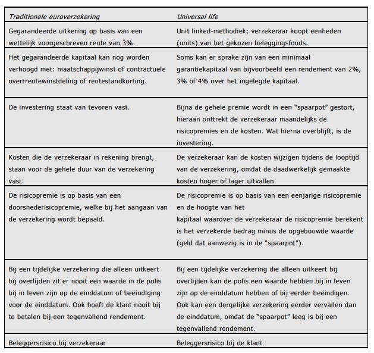

#### 4.3 Premie- of koopsomberekening

voor berekening van de uiteindelijke premie of koopsom maakt de verzekeraar gebruik van:

- offertesoftware
  - behalve verzekereraars maken ook veel bemiddelaars gebruik van offertesoftware, zodat ook zij snel een offerte kunnen maken.
- tarievenboeken
  - gevuld met tabellen waarin per EUR 10.000 verzekerd kapitaal of per EUR 1.000 verzekerde rente het tarief weergeeft.
- aangevraagde offertes
  - kunnen alleen via de verzekeraar zelf worden aangevraagd.
  - Gaat om specialistische berekeningen of actuele feiten zoals rentestanden.

## 5 Soorten levensverzekeringen

*(pg 35-53)*

#### 5.1 Indeling van levensverzekeringen

1. de wijze van uitkeren
   - *kapitaalverzekering*. Deze keren een bedrag ineens uit
   - *renteverzekeringen*. Deze keren periodiek een bedrag uit.
2. het moment van uitkeren
   - *risicoverzekeringen*. Keren uit na overlijden van een persoon.
   - *spaarverzekeringen*. Keren uit na het bereiken van een bepaalde leeftijd.
   - *mengverzekeringen*. Keren uit zowel bij overlijden als op een bepaalde datum.

Op basis van de bovenstaande indeling kan hieronder in de tabel een overzicht van verschillende verzekeringen gevonden worden.

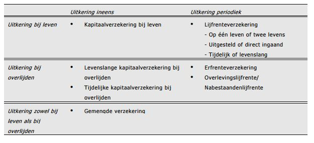

1. kapitaalverzekering bij leven.

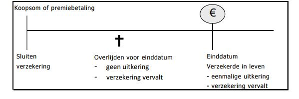

   - premie wordt doorbetaald tot de einddatum of tot het overlijden van de verzekerde.
   - betaling door middel van koopsom is ook mogelijk.
2. levenslange kapitaalverzekering bij overlijden.

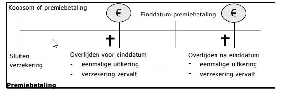

   - premiebetaling kan zowel levenslang zijn als tot een afgesproken einddatum.
   - betaling door middel van koopsom is ook mogelijk.
3. tijdelijke kapitaalverzekering bij overlijden.

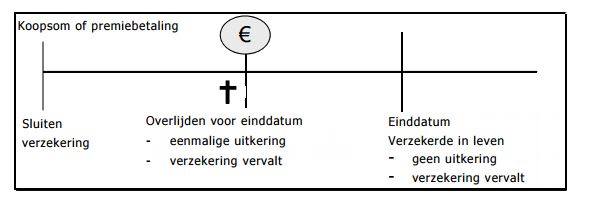

   - premiebetaling vind plaats tot de einddatum van de verzekering, of tot het overlijden van de verzekerde.
   - koopsom is mogelijk, maar ongebruikelijk.

Naast de standaard tijdelijke overlijdensrisicoverzekering (`ORV`) zijn er twee varianten:

1. lineair dalend.
   - elk jaar is de daling even veel.
   - afhankelijk van de looptijd en het oorspronklijk verzekerde bedrag.
2. annuïtair dalend.
   - de daling van het verzekerde bedrag loopt toe naarmate meer tijd is verstreken.
   - wordt vaak in combinatie met een hypothecair crediet afgesloten.

Een schematische illustratie van de meng-verzekeringsvorm is hieronder te vinden.

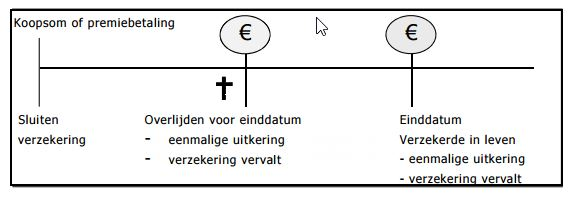

Bij de kapitaalverzekering bij leven met restitutie is er uitkering als:

- de verzekerde op de einddatum in leven is.
- bij overlijden voor de einddatum wordt de som van de betaalde premies of de opgebouwde waarde uitbetaald met 90%, 100% of 110% restitutie.

#### 5.5 Kapitaalverzekeringen en belasting.

1. *Wet IB 2001*, geldt voor polissen gesloten na 14-09-1999.
   - polissen vallende onder deze wet vallen in beginsel onder de vermogensrendementsheffing box 3.
   - met betrekking tot de voorwaarden voor de `KEW`, spaarrekening eigen woning, `SEW` en de beleggersrecht eigen woning, `BEW`, gelden de volgende:
     - bandbreedte-eis van 1:10
     - minimale looptijd 15 jaar, of tot het overlijdenv an de verzekerde/rekeninghouder.
     - maximale looptijd 30 jaar.
     - eenmalige uitkering ter aflossing van de eigenwoningschuld van de belastingsplichtige of diens partner.
     - professionele bank of verzekeraar.
     - belastingvrije uitkeringen (vrijstellingen).
       - bij 15 jaar premiebetaling een vrijstelling van ongeveer EUR 37.500
       - bij 20 jaar premiebetaling een vrijstelling van ongeveer EUR 163.000
     - afhankelijk van de vorm kan er gespaard en/of belegd worden.
     - de verhuisregeling geld voor 3 jaar.
       - = de verzekerde verkoopt diens woning, gaat tijdelijk huren en vervolgens weer een woning koopt.
   - op de `KEW` wordt de desbetreffende clausule opgenomen, bij een `SEW` en `BEW` is het niet mogelijk om een clausule te plaatsen, in plaats daarvan zal de bank ze administreren als geblokkeerde rekeningen ten behoeve van de eigen woning.
     - na de maximale looptijd worden de `SEW` en `BEW` gedeblokkeerd.
   - het gaat om de woning die door de belastingsplichtige of diens partner als hoofdverblijf ter beschikking staat. d.w.z. vakantiewoningen zijn uigesloten.
   - de vrijstelling is life time, d.w.z. iedere Nederlander heeft eenmaal in zijn leven recht op deze vrijstelling.
   - sinds 01-01-2016 is het mogelijk voor de belastingsplichtige die het gehele jaar een fiscale partner heeft de vrijstelling van die partner in de uitkering te betrekken. Nu komt de helft van de waarde in mindering op de eigen vrijstelling.
   - als de uitkering hoger is dan de vrijstelling, dan zal alleen het rentebestanddeel van het niet-vrijgestelde deel van de uitkering worden belast.
     - de volgende formule wordt hierbij gehanteerd:
       $$((U-V)/U)*(U-P)$$
     - waarbij $U$ = uitkering, $V$ = vrijstelling en $P$ = de som van de betaalde premies.
     - dit bedrag dient te worden opgeteld in box 1, dus hierover wordt progressief afgerekend.
   - na 01-01-2013 is het niet meer mogeljk het eindkapitaal of de premie te verhogen, en is het niet meer mogelijk nieuwe kapitaalverzekeringen/-rekeningen af te sluiten in box 1.
     1. uitgezonderd: indien er op 31-12-2012 een eigen woning en een eigenwoningschuld aanwezig is mocht er tot 01-04-2013:
        - een nieuwe `KEW`, `SEW` of `BEW` gesloten worden, of een bestaande worden verhoogd qua premie of inleg of de looptijd worden verlengt.
        - bestaande box 3-polis omgezet worden naar `KEW`, `SEW` of `BEW`.
     2. uitgezonderd: tot 01-01-2014 mocht er nog een nieuwe `KEW`, `SEW` of `BEW` gesloten worden, indien er op 31-12-2012 sprake was van:
        - een onherroepelijke koopovereenkomst of de (ver)koopprijs moet in een echtscheidingsconvenant zijn vastgesteld.
        - een onherroepelijke koop-/aannemingsovereenkomst
        - een offerte voor verbetering of onderhoud van de woning.
   - Het omzetten van de verschillende vormen is mogelijk tot aan de einddatum.
     - Het omzetten van een `KEW` met een gegarandeerd kapitaal naar een `SEW` met hetzelfde gegarandeerde kapitaal behoud het overgangsrecht.
     - bij het omzetten van een `KEW` met een niet-gegarandeerd kapitaal moet worden uitgegaan van het contractueel overeengekomen bedrag van de premie. Het overgangsrecht wordt behouden indien de inlig van de `SEW` of `BEW` niet hoger is dan de totale `KEW`-premie.
   - een losse `ORV` is voor het omzetten van een `KEW` naar een `SEW` of `BEW` niet verplicht, en heeft indien wel al afgesloten geen fiscaal verband met deze.
   - verschillen tussen de `KEW` en een `BEW`/`SEW` kunnen in onderstaande figuur gevonden worden.

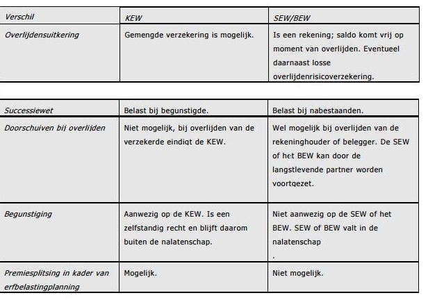

   - bij scheiding:
     - *splitsing*. De polissen worden gesplitst die worden gezien als fiscale voortzetting van de eerste.
     - - toewijzing aan de andere partner*. Bij een niet-garantieproduct mag de totale premie stijgen. bij een garantieproduct mag dit NIET.
     - *afkopen*. De polis wordt afgekocht zonder fiscale consequenties. De 20-jaarsvrijstelling wordt geïmputeerd.
   - andere situaties wat tot uitkering leidt:
     - verkoop van de woning met verlies.
     - sprake van schuldsanering.
     - overlijden.
     - verkoop en verhuizing naar huurwoning.
     - emigratie.
   - bij een latere aankoop dient dit in mindering te worden gebracht op de nieuwe eigenwoningschuld.
2. *Brede Herwaarderingspolis/periode*, polissen gesloten tussen 01-01-1992 en 14-09-1999 (hierbij rekening te houden met de looptijd en het moment van uitkeren)
   - tijdens de looptijd:
     - polissen vallen in box 3.
     - de gezamelijke waardevrijstelling in box 3 voor vermogenrendementsheffing is EUR 123.428.
       - indien de waarde op 31-12-2000 hoger dan EUR 123.428 is, dan wordt de vrijstelling in box 3 de waarde op 31-12-2000.
       - indien de waarde na 01-01-2001 hoger dan EUR 123.428 is, dan wordt het meerdere meegenomen voor de vermogensrendementsheffing.
       - de vrijstelling mag worden verdubbeld met een fiscaal partner.
       - deze vrijstellingen komen te vervallen met ingang van 14-09-2029.
   - moment van uitkeren.
     - belast in box 1.
     - de polis is onbelast indien:
       - bandbreedte-eis van 1:10.
       - minimale looptijd van 15 jaar.
       - eenmalige uitkering.
       - het verzekerde kapitaal is na 13-09-1999 niet verhoogd.
       - de duur van de verzekering is na 13-09-1999 niet verlengd.
       - uitkeringsvrijstelling van:
         - EUR 28.134 bij 15 jaar.
         - EUR 123.428 bij 20 jaar.
         - indien hoger, saldomethode.
   - sinds 01-01-2016 is het mogelijk om de vrijstelling van een fiscale partner van >= 1 jaar in mindering op de eigen vrijstelling te betrekken.
3. *Pre-Brede Herwaarderingspolis*, polissen gesloten voor 01-01-1992.
   - polissen vallen in box 3
   - op het moment van uitkeren:
     - voor onbeperkte vrijstelling van box 1 moet:
       - er een variabele bandbreedte zijn.
       - er een minimale looptijd van 12 jaar zijn.
       - het verzekerde kapitaal na 01-01-1992 niet zijn verhoogd.
       - de duur van de verzekering na 01-01-1992 niet zijn verlengd.
     - tot 01-04-2013 konden deze polissen omgezet worden naar een `KEW`/`BEW`/`SEW`.
       - de vrijstelling in box 1 werd verhoogd met de waarde op het moment van verpanden.

**NB.** Belastingvrije uitkeringen vallen onder de imputatieregeling, d.w.z. deze tast de vrijstelling aan. Dus, de lifetime-vrijstelling wordt gekort (geïmputeerd) met de uitkering van een vrijgestelde `KEW`. Sinds 01-01-2016 vallen ook de `SEW` en `BEW` onder de imputatieregeling.

#### 5.6 Uitvaartverzekering en uitvaartbankrekening.

De uitvaart verzekering is een levenslange overlijdensrisicoverzekering, deze keert alleen uit bij het overlijden. i.t.t. andere `ORV` heeft de uitvaartverzekering een waarde, en heeft een beperkte vrijstelling van EUR 7.000 in box 3. Als deze waarde wordt overtroffen, dan wordt de *gehele* waarde in de heffing betrokken. Het vrijgestelde bedrag is geïndexeerd aan de inflatie. De twee soorten uitvaartverzekeringen:

1. *Kapitaalverzekering*. De begunstigde krijgt een bedrag uitgekeerd waarmee hij de uitvaart betaalt.
2. *Naturaverzekering*. De begunstigde krijgt geen geld. De uitvaart zelf, komt voor rekening voor de verzekeraar. Hierbij wordt vaak een standaarpakket gehanteerd waarbij extra’s via aanvullende verzekeringen kunnen worden geregeld.

Van 01-01-2010 tot 01-01-2016 was het mogelijk te sparen via een geblokkeerde uitvaartrekening. Dit product werd niet in de praktijk aangeboden, dus de vrijstelling is vervallen.

#### 5.7 Lijfrenteverzekering.

Dit is een periodieke uitkering bij leven. Twee vormen:

1. *direct ingaande lijfrente*. Deze start direct na ontvangst van de koopsom en gaat door tot de gekozen einddatum.
   - hieronder schematisch de verschillende vormen aangegeven:

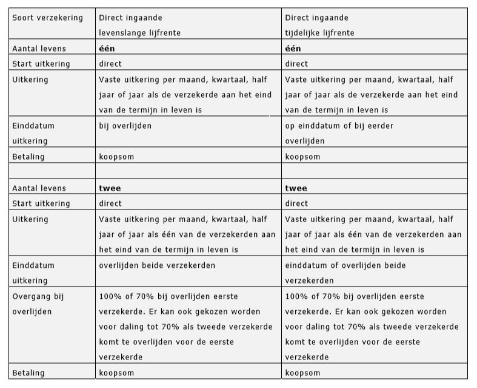

2. *uitgestelde lijfrente*. Deze gaat in op een vooraf gesproken moment tot de gekozen einddatum.
   - hieronder schematisch de verschillende vormen aangegeven:

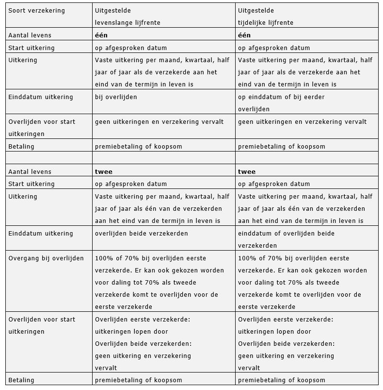

Een periodieke uitkering ten behoeve van de nabestaande kent de volgende vormen:

- Overlevingsrente/nabestaandenlijfrente.
  - uitgestelde lijfrente
  - een periodieke uitkering bij het overlijden van de verzekerde t.b.v. de medeverzekerde, mits deze in leven is.
    - *levenslang*. Keert uit vanaf het overlijden van van de verzekerde voor de einddatum en uit tot en met het overlijden van de medeverzekerde.
    - *tijdelijk*. Keert uit vanaf het overlijden van de verzekerde voor de einddatum en uit tot de einddatum of het overlijden van de medeverzekerde.
  - komt de medeverzekerde eerder te overlijden dan de verzekerde, vervalt de verzekering.
  - premiebetaling is vanaf de ingangsdatum tot het moment van uitkeren of tot het overlijden van de medeverzekerde.
  - specifieke vormen van overlevingsrente: weduwenrenteverzekering, weduwnaarsrenteverzekering en de wezenverzekering.
- Erfrente.
  - een speciale vorm van tijdelijke kapitaalverzekering bij overlijden.
  - geen uitkering ineens, maar van een jaarlijkse rente tot de einddatum van de verzekering.
  - slechts uitkering als de verzekerde komt te overlijden voor de einddatum van de verzekering, daarna vervalt de verzekering.
  - uitkeringen zijn niet afhankelijk van leven of dood van de begunstigde.
  - indien er een waarde is, dan vermogensrendementsheffing in box 3.
  - periodieke uitkeringen zijn onbelast.
  - premiebetaling eindigt met het overlijden van de verzekerde.
  - discontoclausule = het ineens laten uitbetalen van de periodieke uitkeringen.
    - dit is lager dan het totaal aan periodiek uitkeringen, vanwege het gemis aan rente voor de verzekeraar.

## 6 Lijfrenten

*(pg 55-79)*

#### 6.1 Wat is een lijfrente?

Lijfrenten zijn toekomstvoorzieningen. Bijvoorbeeld ter aanvulling van AOW en pensioen. Voor 01-01-2008 was het alleen mogelijk een lijfrente te ontvangen via een verzekering, sedert is het ook mogelijk een periodieke uitkering van een saldo van een bankrekening.

Onderstaand schematisch weergegeven wat een lijfrente is.

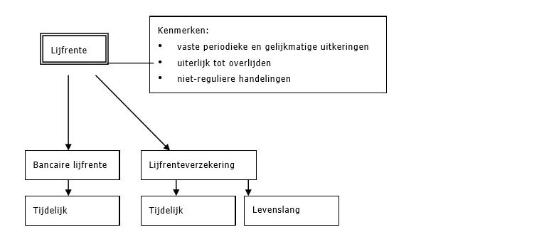

#### 6.2 Opbouw- en uitkeringsfase

Twee fases:

1. *opbouwfase* = geen uitkering, klant bouwt kapitaal op.
2. *uitkeringsfase* = een periodieke en vaste uitkering. Ook wel de afbouwfase.

#### 6.3 Benamingen van lijfrenteverzekeringen

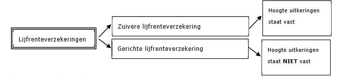

#### 6.4 Huidige fiscale behandeling lijfrenten.

- het inkomen in box 1 in het jaar voor aftrek van de inleg.
- de hoogte van de pensioenopbouw voor het jaar van aftrek van de inleg.

Box 3-lijfrenten worden belast tegen 30% inkomsten belasting tegen 4% van de waarde, terwijl de uitkeringen zelf niet worden belast.

#### 6.5 Toegestane lijfrentevormen

Drie lijfrentevormen die vaak worden toegepast:

1. de levenslange oudedagslijfrente
2. de tijdelijke oudedagslijfrente
3. de nabestaandenlijfrente

Deze kunnen zowel via verzekering als via een rekening worden afgesloten. De volgende vormen zijn alleen via verzekering af te sluiten.

1. de overbruggingslijfrente
2. de lijfrente voor een meerderjarig invalide kind
3. de lijfrente voor de afkoop van alimentatie en/of ter verrekening van pensioenrechten
- Onderstaand de verschillen tussen de tijdelijke en levenslange oudedagslijfrente.

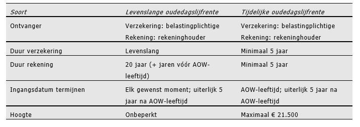

De lijfrente-uitkeringen moeten uiterlijk ingaan op het kalenderjaar waarop de ontvanger 5 jaar boven de AOW-gerechtigde leeftijd is gekomen. Uitzonderingen hierop zijn bij stakingswinst of oudedagsreserve.

Als overgangsrecht voor de verandering van de pensioensleeftijd mogen mensen die via een bancaire of verzekerde lijfrente kapitaal hebben opgebouwd tot en met 2013 mogen nog een tijdelijke oudedagslijfrente aankopen vanaf de leeftijd van 65 jaar.

Hieronder een tabel met verschillen tussen verzekering en bancaire lijfrente.

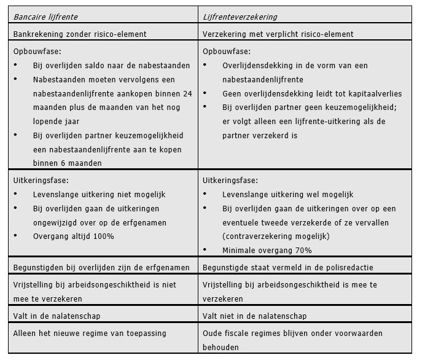

Hiernaast is een verschil dat er bij bancaire producten geen risico-elementen omdat het een rekening is, in tegenstelling tot een verzekering.

*contraverzekering* = een verzekering die een uitkering geeft bij overlijden ter hoogte van de inleg min de gedane uitkeringen. Dit heeft een hogere premie tot gevolg. Is niet aftrekbaar want het betreft een risicokapitaalverzekering. De uitkering is ook onbelast.

- Nabestaande lijfrente.
  - wordt altijd aan een natuurlijk persoon uitgekeerd, dus geen rechtspersoon.
  - Nabestaande is een ruim begrip hier.
    - bloederwanten in de rechte lijn, of in de tweede en derde graad van de zijlijn. Echtgenoot valt niet in deze groep.
  - onderscheid in lijfrenteverzekering en bancaire lijfrente. Hieronder in tabelvorm weergegeven.

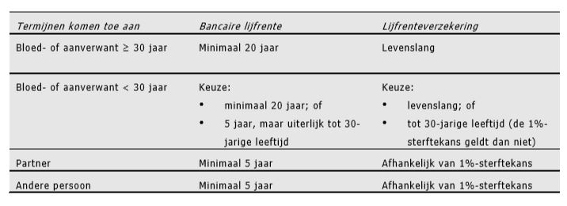

  - de begunstigde moet statistisch gezien binnen de looptijd 1% kans hebben te overlijden. Dit heet de 1%-sterftekans. VOor een jongere persoon is de uitkeringsduur dus langer dan een oudere persoon.
  - nabestaandelijfrente dient direct in te gaan.
    - Uitzondering hierop is als de nabestaande `ANW` ontvangt, dan kan de lijfrente ingaan na afloop van de `ANW`.
  - omzetting zonder heffing kan alleen:
    - als de verzekering is afgesloten voor 01-01-2001, of
    - als de verzekering is afgesloten na 01-01-2001, waarbij de lijfrente ontstaat door het overlijden van de partner van de verzekeringnemer.
- Overbruggingslijfrente.
  - tot 01-01-2006 was het mogelijk om deze af te sluiten in box 1.
    - een overbruggingslijfrente loopt van een periode voor de AOW-leeftijd tot de einddatum van de AOW-leeftijd.
    - bij het overgangsrecht is het van belang over er na 01-01-2006 nog premies zijn betaald.
      - *geen premies* -> De volledige waarde kan worden aagewend voor het kopen van een overbruggingslijfrente.
      - *wel premies* -> De waarde op 31-12-2005 kan worden aangewend voor het kopen van een overbruggingslijfrente.
        - De waarde na deze datum kan worden gebruikt voor een tijdelijke oudedagslijfrente.
    - tijdens de opbouwfase kan het saldo van een overbruggingslijfrente worden doorgestort naar een bancaire lijfrente. Deze komt tot uitkering op het moment dat de lijfrente expireert.
  - na 01-01-2006 is het niet meer mogelijk om overbruggingslijfrentes nieuw af te sluiten in box 1. Dit moet nu gebeuren in box 3.
    - De waarde telt mee voor de vermogensrendementsheffing.
    - worden nauwelijks meer afgesloten.
- Lijfrente voor meerderjarig invalide kind
  - komt toe aan het eigen invalide kind.
  - gaat in op de leeftijd van meerderjarigheid.
  - keert levenslang uit.
  - de hoogte van de premieaftrek is niet beperkt.
  - grootouders kunnen ook inleggen voor kleinkinderen.
- pre-BHW & BHW
  - BHW-polissen zijn vergelijkbaar als die van IB-2001.
    - kunnen worden omgezet naar een bankspaarproduct, maar vallen dan wel onder de regels van IB-2001.
    - Op lijfrentes met koopsom voor 01-01-1992 en lijfrentes met premie voor 16-10-1990 zijn pre-BHW regels van toepassing.
      - premies betaald na 01-01-2001 worden getoetst aan de nieuwe regelgeving.
      - vaak nieuwe polis afsluiten en hier aan verbinden.
  - onderstaand een tabel met kenmerken van de regimes.

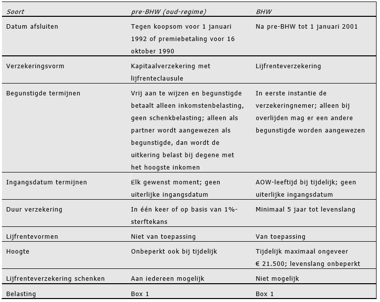

#### 6.6 De aftrekbaarheid van de inleg

1. *de jaarruimte* = de berekening naar de mogelijkhei om de lijfrente-inleg af te trekken van het fiscale inkomen.
   - Alleen voor mensen die de AOW-leeftijd nog niet hebben bereikt.
   - de formule is als volgt:
     $$0.138 * (Ig - AF) - 6.5 * A - F$$
   - waarbij $Ig$ = inkomensgrondslag, $AF$ = AOW-franchise, $A$ = Factor A, en $F$ = dotatie van de fiscale oudedagsreserve in het voorafgaande kalenderjaar.
     - de inkomensgrondslag bestaat uit:
       - winst uit onderneming
       - belastbaar loon
       - belastbaar resultaat uit overige werkzaamheden
       - belastbare periodieke uitkeringen en verstrekkingen.
     - de AOW-franchise wordt jaarlijks door de overheid vastgesteld.
       - is nu ongeveer EUR 12.000
       - **NB.** Dit is een andere dan die van pensioen.
     - de maximale premiegrondslag is EUR 103.000 - EUR 12.000 = EUR 91.000.
     - Factor A is de aangroei van van het pensioen in het voorgaande kalenderjaar.
       - aangegeven in het UPO.
2. *de reserveringsruimte (inhaalruimte)* = de mogelijkheid gemiste jaarruimte in te halen.
   - drie maxima:
     1. de berekening van de totale jaarruimtes over de afgelopen 7 jaar.
     2. maximaal 17% van de premietoeslag van het jaar van aftrek.
     3. een absoluut bedrag van ongeveer maximaal EUR 7200.
   - belangrijke punten:
     1. eerder in aftrek gebrachte lijfrentepremies verlagen de reserveringsruimte.
     2. de franchise betreft deze van het jaar waarin de aftrek wordt aangevraagd.
3. *terugstorten*.
   - onterecht overgemaakte inleg dienen binnen 3 maanden teruggestort te worden.
   - een tijdelijke regeling maakt het mogelijk om onterechte inleg van voor 31-12-2016 terug te laten storten.
     - mag niet verder dan 5 jaar terug.
   - voorwaarden:
     - verzoek bij belastinginspecteur voor terugstorting
     - moet voor 31-12-2017 bij inspecteur zijn ontvangen.
     - zijn er nog mogelijkheden voor aftrek, moeten deze worden benut
     - het bedrag moet worden opgenomen in de grondslag van box 3.

#### 6.7 Inhoudingsverplichtingen

d.w.z. de lijfrente-uitvoerder dragen loonbelasting af over de uitkeringen.

#### 6.8 Moment van aftrek

De terugwentelingsmogelijkheid is de mogelijkheid om de premies af te trekken bij een omzetting van een oudedagsreserve en stakingswinst in een lijfrente. Deze premies dienen voor 01-07-2017 te zijn betaald om over belastingjaar 2016 in de aftrek meegenomen te worden. Deze mogelijkheid bestaat niet voor de jaar- of reserveringsruimte.

#### 6.9 Saldomethode

Het is aan de verzekeraar verplicht om de opgave te doen van het box 3-deel. Als de polis tot uitkeren komt, is over dit box 3-deel geen inkomsten-belasting verschuldigd. Dit heet de saldo methode. Om tijd en geld te besparen, is sinds 01-01-2010 de beperkte saldomethode ingevoerd.

- Beperkte saldomethode.
  - geen splitsing meer.
  - de termijnen zijn volledig belast in box 1.
  - de niet-afgetrokken bedragen mogen tot een max van EUR 2.269 per jaaar in mindering brengen op de lijfrente-uitkeringen.

#### 6.10 Niet-reguliere uitvoering

Een niet-reguliere uitvoering van lijfrente houd in dat de lijfrente niet is gebruikt als inkomensvoorziening. Vanuit de wet IB 2001 volgen hier een aantal sancties op.

- Sancties
  - *bijtelling van de waarde*. De afkoopwaarde van de lijfrenteverzekering wordt opgeteld bij het inkomen in box 1.
  - *revisierente*. Dit is een boete van 20% van de waarde van de verzekering op het moment van uitvoeren van de niet-reguliere handeling.
- *De minimumwaarderingsregeling (tot 09-2015)*. Indien de ingelegde premies hoger dan de waarde, moest ingelegde premies worden opgeteld bij het inkomen i.p.v. de waarde van de polis.
- Kleine lijfrentekapitalen < EUR 4.400 kunnen zonder verschuldiging van de revisierente worden afgekocht.
  - dit bedrag is per lijfrentecontract.
  - meerdere lijfrentes bij dezelfde verzekeraar worden bij elkaar opgeteld.
- Afkoop bij arbeidsongeschiktheid.
  - vanaf 01-01-2015 is het mogelijk om nog niet-ingegane box 1 lijfrentes af te kopen zonder revisierente te betalen.
    - de persoon moet langdurig arbeidsongeschikt zijn.
      - niet meer volledig de werkzaamheden kunnen verrichten waarmee hiervoor het inkomen werd verdiend.
      - is hiertoe vermoedelijk in de komende twaalf maanden ook niet meer toe in staat.
    - mag nog niet op AOW leeftijd zijn
    - mag niet hoger zijn dan het hoogste van EUR 40.000 of het gemiddelde inkomen van de 2 jaren voorafgaand ana het jaar van afkoop.
  - dit is ook mogelijk voor box 3 nettolijfrentes, met uitzondering van de inkomenseis.
    - deze wordt afgetopt boven de EUR 103.000 met een nettofactor van 0.48.
- Emigratie.
  - bij emigranten worden zg. conserverende aanslagen opgelegd door de fiscus.
    - dit ter veiligstelling van belasting over de uitkering die anders misgelopen zouden worden.
    - binnen europa mogen geen zekerheden worden aangevraagd.
    - de hoogte van deze aanslag is hetzelfde als van een niet-reguliere uitvoering.
- Omzetting.
  - omzetting tussen de verschillende vormen is in alle fases fiscaal mogelijk.
    - rekening dient gehouden te worden met de specifieke regimes.

#### 6.11 Transitievergoeding

Overgangsregime tot 01-01-2020:

- werkgevers hoeven alleen de dienstjaren na 1 mei 2013 te betalen indien:
  - slechte financiële positie en,
  - minder dan 25 werknermers in dienst.

Ontslagvergoeding en stamrecht.

- tot 2014 was het mogelijk een ontslagvergoeding met zg. stamrecht aan te kopen.
  - de hoogte werd bepaald door kantonrechtersformule.
  - in de regel hoger dan de transitievergoeding.
  - is een lijfrenteverzekering want:
    - periodieke uitkering bij het in leven zijn van een persoon.
  - diverse mogelijkheden van uitkering:
    - direct uit laten keren.
    - stamrechtlijfrente aankopen bij een bank of verzekeraar.
    - een stamrecht Besloten Vennootschap, `BV`, opzettten.
      - de laatste twee kunnen als:
      - tijdelijke lijfrente tot aan AOW of werk uitkeren.
        - uitkeringsduur afhankelijk van 1%-sterftekans.
        - bij werk, uitkering doorschuiven naar pensioen.
      - direct ingaande levenslange lijfrente.
      - (tijdelijke) oudedagslijfrente die uiterlijk in gaat op AOW.
    - bij een stamrecht BV:
      - meer flexibiliteit; kan naar eigen inzicht worden belegd, eigen bedrijf mee opstarten.
      - kosten voor oprichten BV en inschrijven KVK, worden in mindering gebracht op het kapitaal.
      - jaarlijks een jaarverslag moeten opstellen.
  - mogelijkheid stamrecht af te kopen.
    - tot 2014 80% van de waarde opgeteld bij het inkomen.
    - daarna volledige waarde.
    - in box 1, geen revisierente.

#### 6.12 Echtscheiding en lijfrenten

Het het verdelen van de gemeenschap bij scheiding is het mogelijk dat er een lijfrentevoorziening behoort. Als er overbedeling, d.w.z. één partner ontvangt meer dan de ander, is dan kan er sprake zijn van schenkbelasting.

Als een van de partners de box 1-lijfrentes ontvangt, wordt er op het te compenseren bedrag een z.g.n. latente belastingclaim ingehouden. Dit is om uit te balanceren dat er over de lijfrente nog belasting gaat worden betaald. Bij aanspraken van lijfrenten voor 01-01-2001 vind er verdeling zonder belasting plaats.

In het huidige regime kan lijfrentes belastingvrij worden verdeeld als:

- de lijfrente wordt overgedragen.
- de ex-echtgenoot wordt onherroepelijke begunstigde.
- deze wordt omgezet in een lijfrente die kwalificeert voor lijfrentepremieaftrek ten behoeve van de ex-echtgenoot.

Box 3-lijfrentes en goudenhanddrukstamrechten kunnen ook zonder fiscale gevolgen worden verdeeld.

De ex-echtgenoot wordt belastingsplichtige over de lijfrente.

#### 6.13 Wet VPL

*Wet aanpassing fiscale behandeling VUT, prepensioen en introductie levensloop* = `VPL`, geïntroduceerd op 01-01-2005.

## 7 Wet Inkomstenbelasting 2001

*(pg 81-98)*

Het huidige belastingregime IB 2001 werd in het jaar 2001 geïntroduceerd, met de volgende doelstellingen:

- verbreding en versterking van de belastinggrondslag.
- bevordering van de werkgelegenheid en de economische structuur, versterking concurrentiekracht van Nederland.
- verlaging van de lastendruk op arbeid.
- bevordering van een duurzame economische ontwikkeling (‘vergroening’).
- een evenwichtige en rechtvaardige belastingdruk.
- bevordering van emancipatie en economische zelfstandigheid.
- vereenvoudiging van het belastingstelsel.

#### 7.1 Boxenstelsel

Geen sprake van één totaalinkomen maar drie afzonderlijk belastte inkomens.

1. *box 1*. Belastbaar inkomen uit werk en woning. (oplopend naar 50%)
2. *box 2*. Belastbaarinkomen uit aanmerkelijk belang. (vast tarief van 25%)
3. *box 3*. Belastbaar inkomen uit sparen en beleggen. (vast tarief van 30%)

**NB.** inkomsten mogen maar in één box belast worden ter voorkomen van dubbele belastingheffing.

Een negatief inkomen in een box kan niet worden verrekend met een positief inkomen uit een andere box. Binnen box 1 en 2 is het wel mogelijk een verrekening te doen met een positief inkomen uit volgend of vorige jaren.

#### 7.2 Overzicht heffingsgrondslag en verschuldigde inkomstenbelasting.

Schematisch overzich over de totale heffingsgrondslag:

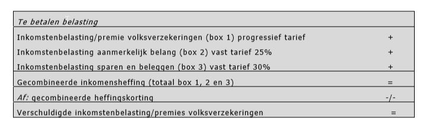

#### 7.3 Individuele belastingheffing

- Elke belastingsplichtige wordt individueel belast.
- Samenwoners worden apart belast.
- Uitzonderingen door fiscaal partnerschap.

#### 7.4 Fiscaal partnerschap

Fiscaal partnerschap = bepaalde inkomsten en aftrekposten mogen zelf bepaald worden wie wat betaald in de belastingaangifte. Inkomsten en aftrekposten die partners kunnen verdelen:

- belastbare inkomsten uit eigen woning
  - zolang het totaal van 100% wordt behaald is de verdeling geheel vrij.
- inkomen uit aanmerkelijk belang voor vermindering met de persoonsgebonden aftrek.
- persoonsgebonden aftrek
- de gezamelijke grondslag voor fictieve inkomsten uit bezittingen en schulden van box 3.

Gehuwden en geregistreerde partners zijn automatisch fiscale partners. tot 01-01-2011 konden ongehuwde samenwoners kiezen voor fiscaal partnerschap, sindien onder bepaalde voorwaarden, namelijk alle hoofdvereisten en ten minste 1 van de zes subvereisten.

- *Hoofdvereisten*:
  - ingeschreven op hetzelfde woonadres in de Basisregistratie personen (BRP).
  - Beiden zijn meerderjarig.
  - Gezamenlijke huishouding, geen zakelijke huurovereenkomst.
- *Subvereisten*:
  - notariaal samenlevingscontract.
  - (erkend) kind.
  - aangemeld als partner van de belastingplichtige op de pensioenregeling.
  - samen een woning bezitten welke kwalificeert als eigen woning onder IB 2001
  - op het woonadres een minderjarig kind van ten minste een van beiden staat ingeschreven.
  - in het kalenderjaar voorafgaand aan het huidig kalenderjaar reeds fiscaal partner.

#### 7.5 Box 1: Werk en woning

In box 1 zit het belastbare inkomen uit werk en woning, dit bestaat uit:

- belastbare winst uit onderneming.
  - *ondernemer* = iemand die een onderneming zonder rechtspersoonlijkheid drijft.
  - winst uit onderneming wordt berekend als:
    $$O - K = N - OA = FW$$
    waarbij $O$ = Omzet, $K$ = Kosten, $N$ = Nettowinst, $OA$ = ondernemingsaftrek en $FW$ = fiscale winst.
  - winst van een rechtspersoon, zoals een BV of NV, valt niet onder de heffing van inkomstenbelasting.
  - Ondernemersaftrek is mogelijk voor:
    - ondernemers die
    - 18 jaar of ouder zijn en jonger dan AOW-leeftijd en
    - voldoen aan het urencriterium (50% van de werktijd gaat in de onderneming en minimaal 1225 uur per jaar).
  - de zelfstandigenaftrek is een bedrag van EUR 7.300 dat in mindering mag worden gebracht op de winst voordat er belasting over wordt berekend.
  - de MKB-winstvrijstelling bedraagt 14% van de winst na toepassing van de ondernemersaftrek.
- belastbaar loon
  - salaris, pensioeninkomen, sociale uitkeringen, bijtelling van leaseauto.
  - de heffing wordt ingehouden door de werkgever of uitkerende instantie.
  - bij leaseauto dient een pct. van de marktwaarde van de auto bij de inkomsten te berekenen.
    - bij bewijsbaar minder dan 500km privé geen bijtelling.
    - hoogte afhankelijk van de milieuvriendelijkheid.
    - bij auto’s 15 jaar =< is de bijtelling over de waarde vna de auto in het economische verkeer.
    - werkgevers kunnen een eigen bijdrage vragen voor gebruik van lease auto, dit mag in mindering worden gebracht in de fiscale bijtelling.
- belastbaar resultaat uit overige werkzaamheden.
  - voorbeelden van overige werkzaamheden zijn:
    - freelancer
    - gastouder
    - artikelen en boeken schrijven
    - cursussen geven
    - verhuren van een bedrijfspand aan de eigen BV
- belastbare periodieke uitkeringen en verstrekkingen (lijfrenten, alimentatie, etc)
  - de vier hoofdgroepen:
    1. specifieke uitkeringen en verstrekkingen.
    2. lijfrenten en andere periodieke uitkeringen uit een inkomensvoorziening.
    3. uitkeringen en verstrekkingen op grond van een buitenlandse inkomensvoorziening.
    4. uitkeringen op grond van verplichtgestelde deelneming aan een beroeps- of bedrijfstakpensioenregeling.
  - uitzonderingen zijn bijvoorbeeld zorgtoeslag en kinderbijslag.
- belastbare inkomsten uit de eigen woning die hoofdverblijf is (eigenwoningforfait en de voordelen uit de kapitaalverzekering/de spaarrekening/het beleggingsrecht eigen woning verminderd met de aftrekbare kosten).
  - De lening die is aangegaan voor aankoop verbetering of onderhoud van de eigen woning (hypothecair krediet) heet de eigenwoningschuld.
  - de aftrekposten die hier uit vloeit heet de negatieve inkomsten uit de eigen woning.
    - de inkomsten worden berekend door:
      $$F - R = I$$
      waarbij $F$ = eigenwoningforfait, $R$ = rente betaald over de eigenwoningschuld en $I$ = de inkomsten uit eigen woning.
    - het eigenwoningforfait is een pct. van de WOZ-Waarde (Wet waardering onroerende zaken, `WOZ`) van het voorgaande jaar. Dit is meestal 0.75% en het is naar rato van duur.
    - de rente van de eigenwoningschuld mag in mindering wordne gebracht op het eigenwoningforfait.
    - vanaf 01-01-2013 mag alleen de rente op de EWS afgetrokken worden indien de lening wordt afgelost, dus of annuïtair, of lineair.
    - op EWS voor 31-12-2012 zijn de oude regels van kracht.
    - sinds 2014 wordt het tarief voor de aftrekbare kosten jaarlijks met 0.5% verlaagd tot 38%. Dit start in de 4e schijf. Dit geld niet voor het forfait wat volledig belast wordt.
- negatieve uitgaven voor inkomensvoorzieningen (bijvoorbeeld terugave van lijfrentepremies)
- negatieve persoonsgebonden aftrek

dit wordt verminderd met:

- aftrek wegens geen of weinig eigenwoningschuld.
- uitaven voor inkomensvoorzieningen (lijfrentepremie)
- persoonsgebonden aftrek (schoolingsuitgaven, uitgaven voor specifieke zorgkosten, uitgaven voor monumentenpanden en aftrekbare giften)

Schematisch hieronder het schijvensysteem.

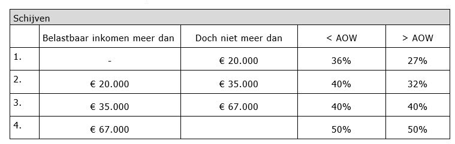

#### 7.6 Box 2: Aanmerkelijk belang

Iemand heeft een aanmerkelijk belang als die tenminste 5% van de aandelen in een BV of NV bezit. De inkomsten hieruit worden dan belast. Denk aan dividend of winst uit verkoop van de aandelen. Er is een vlaktax tarief van 25% in box 2.

Regelingen van toepassing op box 2:

- *meesleepregeling* = overige aandelen, opties, en winstbewzijen van `DGA`behoren ook tot aanmerkelijk belang.
- *meetrekregeling* = de aandelen van de belastingsplichtige zijn ook aanmerkelijk belang als echtgenoot, partner of bloed- of aanverwanten in de rechte lijn een aanmerkelijk belang heeft.
- *terbeschikkingstellingsregeling* = als de `DGA` vermogen beschikking stelt aan de BV. Dit vermogensbestanddeel komt dan voor `DGA` in box 1 terecht.

#### 7.7 BOX 3: Sparen en beleggen

In deze box worden de inkomsten uit sparen en beleggen belast. Hier betaald men een vlaktax van 30%.

1. Stap 1: *Rendementsgrondslag*
   - dit is het totale vermogen dat belast gaat worden.
   - dit is de waarde van de bezittingen minus de waarde van de schulden.
   - het gaat dan om 01-01 van het belastingjaar.
     - veel voorkomende bezittingen:
       - WOZ-waarde tweede woning, vakantiewoning, beleggingspand.
       - saldo op spaar- en beleggingsrekening.
       - waarde van verzekeringen.
       - contant geld boven ongeveer EUR 550 per partner.
     - bij minderjarige kinderen dient de helft van diens vermogen ook bij het eigen vermogen opgeteld te worden.
     - ook het saldo van buitenlandse spaarrekeningen moet worden opgegeven. Zwartspaarders zijn mensen die dit niet doen.
       - de inkeerregeling is voor zwartspaarders. Bij het zelf melden is er een andere boete afhankelijk van het moment van inkeer.
         - vergrijpboete tot 01-07-2014 nihil.
         - vergrijpboete tot 01-07-2015 30%.
         - vergrijpboete vanaf 01-07-2015 60%.
       - als de fiscus de zwartspaarder zelf opspoort kan deze geen gebruik maken van de inkeerregeling.
       - de boete kan oplopen tot 300% van het nagevorderde bedrag.
       - de hoogte van het nagevorderde bedrag is wat de fiscus heeft gemist in de afgelopen jaren met daarover een heffingsrente.
         - De navorderingstermijn voor vermogen in Nederland is 5 jaar, in het buitenland is dat 12 jaar.
   - alle schulden die niet in box 1 of 2 vallen, vallen in box 3. Belastingschulden vallen buiten de rendementsgrondslag, m.u.v. erfbelastingschulden.
     - de eerste EUR 3.500 telt niet mee bij het in mindering brengen van de schulden.
       - dit is dubbel voor partners.
       - dit heet de doelmatigheids- of schuldendrempel.
2. Stap 2: *Rendementsgrondslag minus heffingsvrij vermogen*
   $$GR - HV = GSB$$
   waarbij $GR$ = rendementsgrondslag, $HV$ = heffingsvrij vermogen en $GSB$ = grondslag sparen en beleggen.
   - het heffingsvrij vermogen is het vermogen dat in mindering op het belastbaar vermogen mag worden gebracht.
     - dit is per persoon EUR 21.000
     - dit kan nooit negatief zijn.
   - andere vrijstellingen zijn:
     - groene belegging van EUR 58.000 per persoon.
     - begrafenisverzekering/=rekening van EUR 7.000 per persoon.
     - nettolijfrente en/of = pensioen: onbeperkt.
   - vrijstellingen mogen voor fiscaal partners worden verdubbeld.
3. Stap 3: *Fictief rendement*
   $$GSB * FR = BI$$
   waarbij $GSB$ = grondslag sparen en beleggen, $FR$ = fictief rendement en $BI$ = belastbaar inkomen.
   - fictief rendement of forfaitaire rendement is sinds IB 2001 4%.
4. Stap 4: *hoogte van de belasting*
   $$BI * 0.3 = B$$
   waarbij $BI$ = belastbaar inkomen en $B$ = te betalen belasting in box 3.

Per 01-01-2017 gaat het forfaitfaire rendement gewijzigd worden. De nieuwe structuur is als volgt:

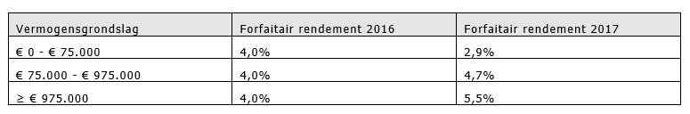

Deze gaan sindsdien jaarlijks opnieuw berekend worden.

#### 7.8 Persoonsgebonden aftrek

Een verzameling van aftrekposten die in mindering worden gebracht in box 1. Als het totaal groter is dan het inkomen in box 1, mag dit ook in box 3 danwel box 2 worden afgetrokken. Het kan nooit tot een negatief inkomen lijden. Een gedeelte van deze aftrek mag ook naar een volgend jaar worden genomen.

Hieronder vallen:

- alimentatieverplichtingen voor de ex-partner
- uitgaven voor specifieke zorgkosten.
- weekenduitgaven voor gehandicapten
- scholingsuitgaven.
- uitgaven voor monumentenpanden
- aftrekbare giften

#### 7.9 Heffingskorting

Heffingskortingen zijn kortingen op de te betalen inkomstenbelasting dus, per euro korting een euro minder belastingbetaling.

Veel voorkomende kortingen zijn:

- Algemene heffingskorting.
  - is afhankelijk van het inkomen uit box 1.
  - schematisch weergegeven:

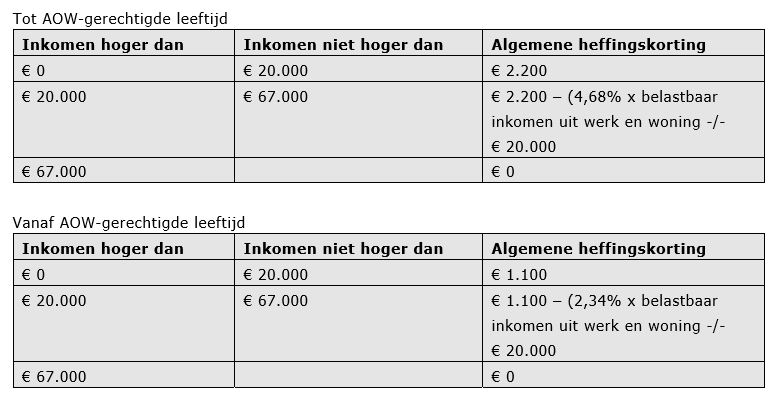

  - aanrechtsubsidie of huisvrouwenkorting is de algemene heffingskorting voor mensen met een partner die voldoende belasting betaald.
- Arbeidskortingen.
  - geldt voor inkomsten uit arbeid
  - is inkomensafhankelijk.
  - splitsing tussen voor en na AOW.
- Groene beleggingen.
  - 0.7% van het ingelegde bedrag tot maximaal EUR 58.000
- Overige kortingen.
  - inkomensafhankelijke combinatiekorting
  - werkbonus
  - ouderenkorting
  - alleenstaande ouderenkorting
- Kindregelingen
  - sinds 01-01-2015 het aantal regelingen beperkt.
  - het kindgebonden budget verhoogd.

#### 7.10 Voorlopige teruggave.

Indien te veel loonbelasting via werkgever betaald, dan kan er een voorlopige teruggaaf worden aangevraagd.

- Periodiek gedurende het lopende jaar terugkrijgen.
- Bijzonder kleine bedragen niet mogelijk.
- Het meest voorkomende bestandsdeel zijn de negatieve inkomsten uit eigen woning.

#### 7.11 Netto inkomen en Netto besteedbaar inkomen.

Het netto inkomen is het bruto inkomen minus de te betalen belasting. Het netto besteedbaar inkomen is het inkomen na vaste lasten en andere netto ontvangsten zoals toeslagen.

## 8 Erfrecht en successiewet

*(pg 99-114)*

## 9 Sociale zekerheid en voorzieningen

*(pg 115-128)*

## 10 Werknemerspensioen

*(pg 131-147)*

#### 10.1 Wat is een werknemerspensioen?

Een werknemerspensioen is een voorziening voor de oude dag, na overlijden of bij arbeidsongeschiktheid van de werknemer die hij kan regelen via de werkgever. + zowel de werkgever als de werknemer betaalt een deel van de pensioenspremie. + Het door de werknemer betaalde deel is de eigen bijdrage, waarover geen loonbelasting is verschuldigd. + de pensioensgerechtigde is de persoon die de pensioenuitkering ontvangt. i.e. de ex-werknemer, diens partner of diens nabestaanden. + over de pensioensuitkering is belasting verschuldigd vanuit box 1. + de pensioenuitvoerder draagt een voorheffing loonbelasting af.

3 soorten pensioen:

1. *ouderdomspensioen*. Komt toe aan de werknemer op het moment van het bereiken van de pensioensgerechtigde leeftijd.
2. *partnerpensioen*. Komt toe aan de partner en kinderen van de werknemer als deze overlijdt.
   - partnerpensioen: voor de partner, hoeft niet gehuwd te zijn, maar wel samenwonend.
   - wezenpensioen: voor de kinderen tot aan de leeftijd van maximaal 30.
3. *arbeidsongeschiktheidspensioen*. Komt toe aan de werknemer indien hij arbeidsongeschikt wordt.
   - uitkering na de eerste 104 weken van ziekte. Werkgever betaald loon door tot die tijd.
   - premievrijstelling is afhankelijk van percentage arbeidsongeschiktheid.

Er is geen algemene pensioenplicht voor de werkgever, noch is het verplicht alle soorten pensioen aan te bieden.

Uitvoerders van pensioenen zijn:

- *ondernemingspensioenfondsen*
  - een onderneming brengt de pensioengelden van diens werknemers in een eigen pensioenfonds. Voor grote ondernemingen.
- *bedrijfstakpensioenfondsen*
  - alle bedrijven van een specifieke tak brengen de gelden samen in een fonds. Valt vaak onder de CAO-afspraken. e.g. bouwnijverheid, detailhandel, metaalnijverheid en zorg en welzijn.
- *beroepspensioenfondsen*
  - Is volgens de Wet verplichte beroepsregeling `Wvb`verplicht voor bepaalde beoefenaren. e.g. medisch specialisten, notarissen, advocaten, huisartsen en dierenartsen. waarbij bij uitzondering zowel de eigenaar van het bedrijf als de werknemers deelnemers zijn aan het fonds.
- *verzekeraars*
  - deze voeren de pensioenovereenkomst uit voor ondernemingen als deze niet onder een voorgenoemde categorie valen, of als er een overeenkomst is boven op de overeenkomst van een ander categorie.
- *premiepensioeninstellingen*
  - bij een premiepensioeninstelling is het alleen mogelijk een premie te beleggen om vermogen op te bouwen. Er mag geen risico’s verzekerd worden. e.g. een periodieke uitkering zolang de ex-werknemer leeft, periodieke uitkering voor de nabestaanden en en een periodieke uitkering bij arbeidsongeschiktheid.
  - garanties op het rendement zijn niet toegestaan.
  - er wordt premie betaald, wat wordt belegd. Het vermogen op de einddatum is de ingelegde premies + rendement.
  - de gerechtigde kan een periodieke uitkering aankopen totdat het geld op is.
  - bestaat sinds 01-01-2011.

#### 10.2 De pensioenovereenkomst

In een cao kan een verplichting tot het aangaan van een pensioenovereenkomst opgenomen zijn. Indien aanwezig is de werkgever gebonden deze na te komen volgens de Pensioen Wet, `PS`. De werkgever moet de uitvoering van het pensioen overdragen aan een pensioenuitvoerder. Dit staat bekend als de onderbrengingsplicht of waarborgingsvoorschrift.

Hieronder staat schematisch de verhoudingen tussen de werknemer, werkgever en pensioenuitvoerder aangegeven.

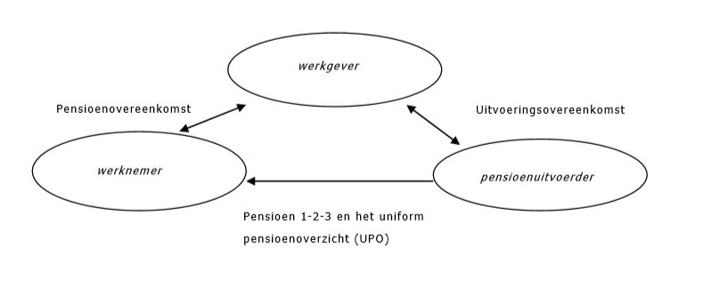

- Uitvoeringsovereenkomst.
  - tussen werkgever en pensioenuitvoerder.
  - eisen volgens `PW` m.b.t.:
    - vastelling van de premie.
    - tijdigheid van betaling.
    - toeslagbeleid.
    - procedures bij wijziging van het reglement.
    - premiekorting.
    - terugstorting van premies.
- Pensioenovereenkomst.
  - tussen werknemer en werkgever.
  - binnen een maand is de werkgever de werknemer verplicht te informeren over het sluiten van een pensioenovereenkomst.
  - de werkgever moet kenbaar maken aan de werkgever wie de pensioenuitvoerder is.
  - de inhoud ligt vast in de arbeidsovereenkomst en het pensioenreglement.

3 soorten pensioenovereenkomsten.

1. *uitkeringsovereenkomst*
   - garandeert hoogte van de maandelijkse uitkering.
   - uitkering is geïndexeerd.
   - beleggingsrisico ligt bij de uitvoerder.
   - e.g. eindloon- en middelloonregeling.
2. *kapitaalovereenkomst*
   - garandeert een vast eindkapitaal.
   - deelnemer ‘shopt’ op de einddatum om een zo hoog mogelijk pensioen te ontvangen
   - beleggersrisico gedeeltelijk bij de uitvoerder gedurende opbouw.
   - beleggersrisico gedeeltelijk bij de werkemer, onbekend op einddatum hoeveel pensioen er aangekocht kan worden.
3. *premieovereenkomst*
   - er wordt een van tevoren afgesproken premie overgemaakt.
   - hiermee wordt doorgaans een beleggig aangekocht (zuivere premieovereenkomst).
   - er kan soms sprake zijn van een gegarandeerd kapitaal en/of met de inleg worden gelijk maandelijkse uitkering ingekocht (niet-zuivere premieovereenkomst).
   - het beleggingsrisico ligt dus meestal volledig bij de deelnemer, tenzij sprake van een gegarandeerd kapitaal of maandelijkse uitkering.

Om heldere en begrijpelijk informatie aan de werknemer te garanderen wordt er gebruik gemaakt van de Pensioen 1-2-3, welke in drie lagen de deelnemer informeerd over de inhoud van de regeling. Deze wordt sinds 01-07-2016 verplicht.

1. *Eerste laag*. De deelnemer krijgt in vijf minuten een globaal inzicht in zijn pensioenregeling.
2. *Tweede laag*. De deelnemer krijgt diepgaander informatie over de pensioenregeling.
3. *Derde laag*. De deelnemer krijgt hier gedetailleerde informatie, zoals het regelement, het jaarverslag en de statuten.
   - de pensioenuitvoerder is volgens de `PW` verplicht om het reglement op te stellen.
   - de werknemer krigt het reglement niet automatisch, maar kan dit opvragen bij diens werkgever.

Sinds 2008 krijgen alle werknemers met een pensioenvoorziening het jaarlijkse Uniform Pensioen Overzicht, `UPO`. ‘Slapers’, d.w.z. ex-werknemers onder de pensioengerechtigde leeftijd, krijgen dit overzicht elke 5 jaar. Het zelfde geld voor ex-partners met een pensioenverevening via echtscheiding.

Op het `UPO` worden de volgende vragen beantwoord: + Voor wie is dit pensioenoverzicht? + Welk pensioen kunt u verwachten? / Welk kapitaal kunt up opbouwen? + Houdt uw pensioen zijn waarde? + Op welke gegevens is uw pensioenoverzicht gebaseerd? + Wat is uw pensioenaangroei?

#### 10.3 Pensioenregister

Hieronder een schematisch overzicht van de verschillen tussen het Pensioenregister en het `UPO`

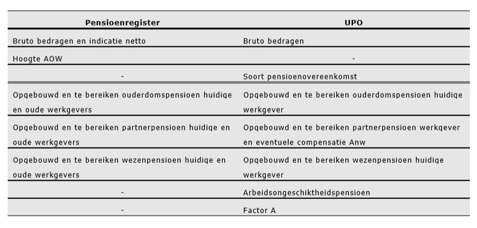

#### 10.4 100%-norm

De richtlijn voor de opbouw is 75% van het gemiddeld genoten salaris inclusief `AOW` in een periode van 40 jaar. Als men langer dan 40 jaar werkt is het fiscaal mogelijk hoger dan deze 75% op te bouwen tot een maximaal 100% van het laatstgenoten salaris.

Op 3 momenten wordt er door de fiscus gekeken of een regeling voldoet aan de 100% norm. + op het moment an ontstaan van de aanspraak op het pensioen. + waarop de pensioenuitkeringen ingaan. + van emigratie van werknemer.

Uitzonderingen op de 100%-norm zijn: + door variabele pensioenuitkeringen. + de laagste pensioenuitkering mag niet minder zijn dan 75% van de hoogste pensioenuitkering. + de variatie mag bepaald zijn voor of op de dag dat het pensioen ingaat. + het omruilen van Nabestaanden- of Partnerpensioen in Ouderdomspensioen. + het aanpassen van pensioenen aan de loon- en prijsontwikkeling. + dit kan door: + *waardevaste indexatie* = volgen de ontwikkeling van het consumentenprijsindex + *welvaartsvaste indexatie* = volgen de ontwikkeling van het loonindexcijfer. + andere manieren van pensioenuitkering zijn: + *nominale waarde* = vast bedrag, geen stijging meer na pensionering. + *toeslag* = stijging volgens een voorgenomen stijgingspercentage met samengestelde rente. + het overdragen van waarde van pensioenen opgebouwd bij een andere werkgever. De opgebouwde pensioenen mogen worden meegenomen naar de nieuwe pensioenuitvoerder.

In een pensioenovereenkomst met een partnerpensioen dat niet verzekerd is op risicobasis is verplicht de werknemer de keuze aan te bieden: + een partnerpensioen. + een hoger of eerder ingaand ouderdomspensioen.

Verzekerd op risicobasis wil zeggen dat er geen partnerpensioen wordt opgebouwd, er is dan een risicoverzekering in de plaats. Er is dan geen uitkering als de werknemer overlijdt na het einde van diens dienstverband, maar voor ingang van de pensioendatum, omdat de verzekering dan al is beëindigd. + Hierop is de uitzondering onbetaald verlof van max. 18 maanden en het ontvangen van een WW-uitkering.

#### 10.5 Toetreding

Toetreding hangt af van: + toetredingsleeftijd + maximale toetredingsleeftijd van 21 jaar. + wachttijd of drempelperiode. + wachtijd: over deze periode wordt geen pensioen opgebouwd en ook niet ingehaald. + drempelperiode: over deze periode wordt geen pensioen opgebouwd, maar wel ingehaald.

#### 10.6 Gelijke Behandeling

Geen discriminatie in welke vorm toegestaan. + mannen en vrouwen + tijdelijke en vaste medewerkers + personen met verschillende leeftijden. + part-time en full-time + soorten partners + gepensioneerde en slapers.

#### 10.7 Afkoop kleine pensioenaanspraken

Afkoop van pensioen is niet toegestaan m.u.v. kleine pensioenen = jaarlijkse uitkering < EUR 475. Dit is alleen een recht van de pensioenuitvoerder, en kan op 2 manieren gebeuren:

1. - zonder toestemming*. Afkoop na twee jaar na beëindiging pensioenregeling, en de deelnemer heeft geen verzoek tot waardeoverdracht gedaan.
2. *met toestemming*. Afkoop na twee en een half jaar na beëindiging pensioenregeling.

#### 10.8 Waardeoverdracht

- *waardeoverdracht bij wisseling van werkgever*
  - een werknemer kan zijn opgebouwde pensioengelden meenemen naar zijn nieuwe pensioenuitvoerder als hij van baan wisselt.
  - sinds 01-01-2015 is er geen termijn meer waarbinnen de waardeoverdracht moet worden aangevraagd.
    - wisselingen hiervoor die de termijn van 6 maanden hebben gemist kunnen niet meer verzoeken om waardeoverdracht. Dit kan pas weer na een nieuwe baanwijzigingen.
  - pensioenuitgevers zijn verplicht om hier aan mee te werken m.u.v.:
    1. de financiële toestand van de nieuwe of oude uitvoerder is niet toereikend voor overdracht.
    2. de opgebouwde aanspraken zijn van een pensioenregeling die voor 08-09-1994 is geëindigd.
- *collectieve waardeoverracht op verzoek van de werkgever*
  - op initiatief van de werkgever.
  - de belangrijkste bepalingen hierbij zijn:
    - de deelnemers mogen geen bezwaar hebben tegen de overdracht.
    - de toezichthouder (DNB) mag geen bezwaar hebben tegen de overdracht.
    - de overdrachtswaarde stelt de uitvoerder vast op basis van collectieve actuariële gelijkwaardigheid.

Soorten wisselingen:

- Inkoop dienstjaren:
  - beschikbare premieregeling -> eindloon/middelloon
  - kapitaalovereenkomst -> eindloon/middelloon
  - eindloon <-> middelloon
- Aanwezige afkoopwaarde:
  - eindloon/middelloon -> beschikbare premieregeling
  - beschikbare premieregeling <-> kapitaalovereenkomst.

#### 10.9 Overige bepalingen

- Uitruil van ouderdomspensioen
  - dit kan op pensioendatum of datum van beëindiging van deelname aan de regeling.
  - het partnerpensioen mag niet hoger worden dan 70% van het ouderdomspensioen.
- Verjaringstermijn
  - er is geen verjarings termijn; een pensioensgerechtigde kan altijd zijn pensioengelden claimen.
- Betalingsachterstanden
  - De werkgever betaald de premie aan de pensioenuitvoerder, dus inclusief:
    - het werknemersdeel
    - de eigen bijdrage van de werknemer
    - de premie voor vrijwillige regelingen
  - De termijn waarbinnen de premie moet worden afgedragen in een maand na afloop van het kalenderkwartaal.
    - achterstanden die een mindering van het pensioen worden verplicht vermeld aan de deelnemer.
  - Deelnemers kunnen de premie rechtstreeks doorbetalen na beëindiging van het dienstverband.

#### 10.10 Zorgplicht volgens WFT

Onderstaand schema geeft weer wanneer de WFT van toepassing is:

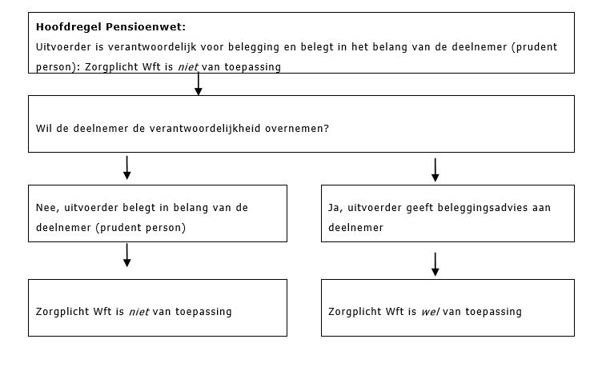

De hoofdregel van de `PW` is dat de pensioenuitvoerder verantwoordelijk is voor de beleggingen en dient te beleggen in het belang van de deelnemers. Dit is de ‘prudent person-regel’. De uitvoerder belegt minder risicovol naarmate de pensioendatum dichterbij komt. Ofwel de `WFT`, ofwel de `PW`is van toepassing betreft zorgplicht.  
De deelnemer kan de verantwoordelijkheid van de beleggingen op zichzelf nemen. In dit geval zijn de bepalingen van de `WFT` van toepassing, dus moet er een klantprofiel aangemaakt worden, en hier in het advies over de beleggingen rekening mee houden.

## 11 Pensioenberekeningen en -systemen

*(pg 149-164)*

Onderstaand schema geeft de maximale hoogte van het pensioen op basis van een middelloonregeling weer.

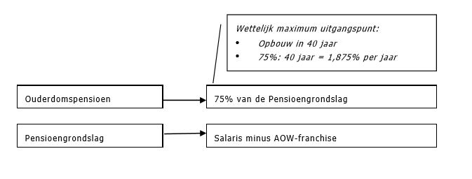

De hoogte van het ouderdomspensioen is afhankelijk van vier variabelen:

1. *pensioengevend salaris*
   - twee soorten regelingen:
     1. eindloonregeling
     2. middelloonregeling

De verschillen tussen de regelingen weergegeven in tabelvorm:

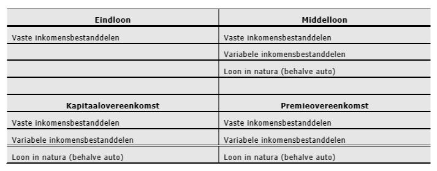

2. *AOW-franchise*
   - afgeleid van de werkelijke AOW-uitkering op het moment van berekenen.
   - hoogte kan worden bepaald door de werkgever, maar er is een wettelijk minimum.

Met het pensioengevend salaris en de AOW-franchise kan de pensioengrondslag worden berekend:

$$PGS - AF = PG$$
Waarbij $PGS$ = pensioengevend salaris, $AF$ = AOW-franchise en $PG$ = pensioengrondslag.

3. *diensttijd*
   - rekening houdend met de maximale toetredingsleeftijd en de mogelijke wachtijd van 2 maanden.
4. *opbouwpercentage*
   - tot en met 2013:
     - 35 jaar, 70% van het laatstgenoten pensioengevend salaris. Dus 2% per jaar voor eindloonregeling.
   - sinds 01-01-2014:
     - 37 jaar, 70% van het laatstgenoten pgs, dus 1.9%.
   - sinds 01-01-2015:
     - 75% van het gemiddeld genoten pensioengevend salaris, over een periode van 40 jaar. Dus 1.875% voor een middelloon regeling, en 1.657% voor een eindloonregeling.

De hoogte van het ouderdomspensioen wordt dus als volgt berekend:

$$PG * OBP * DJ = OP$$
Waarbij $PG$ = pensioengrondslag, $OBP$ = opbouwpercentage, $DJ$ = dienstjaren en $OP$ = ouderdomspensioen. Het pensioen dat wordt opgebouwd gedurende dienstverband heet ook wel tijdsevenredige pensioen (TEP).

Pensioenopbouw boven EUR 103.00 is sinds 2015 beperkt.

- Via de werkgever niet mogelijk.
- Wel mogelijk vrijwillig bij te sparen via nettopensioen/nettolijfrente.
- Deze komt op een 1.875% van het gemiddelde verdiende loon uit.
- Valt onder vrijgesteld vermogen in box 3. Uitkering is onbelast.
- Uitzonderingen bij arbeidsongeschiktheidspensioen.
  - bestaande rechten blijven doorlopen.
  - maximering geld niet voor arbeidsongeschiktheidspensioen.
- Maximering geld wel voor het nabestaandepensioen.

Er zijn drie soorten pensioenovereenkomsten:

1. *uitkeringsovereenkomst*
   - eindloonregeling, dus opbouw over het laatstgenoten salaris. Bij salarisverhoging ook opbouw met terugwerkende kracht, de zgn. *backservice*. Het tegenovergestelde van *comingservice*, het pensioen wat er over de komende jaren nog gaat worden opgebouwd.
   - middelloonregeling. Geen backservice, alleen comingservice.
   - combinatievormen zijn mogelijk, fiscaal wordt dit gezien als twee losse regelingen.
2. *kaptiaalovereenkomst*
   - van te voren overeengekomen bedrag.
3. *premieovereenkomst*
   - De hoogte van de premie staat vast.
   - wordt uitgedrukt in een percentage van het pensioengevend salaris.
   - verplichting een indicatie te geven van het pensioen.
   - werknemer is vrij om zelf een pensioenuitvoerder uit te kiezen
   - niet gesproken over dienstjaren, maar aanwezige waarde.
   - De tabellen waarin de percentages van de pensioengrondslag zijn weergegeven, de zgn. premiestaffels.
   - premiestaffels worden door de Belastingdienst regelmatig gepubliceerd, en geven een richtlijn voor de hoogte van het pensioen.
     - Kosten als onderdeel van de nettopremie:
       - garantieopslagen
       - kosten en premies voor inleggaranties bij beleggingsverzekeringen.
     - kosten als opslag naast de nettopremie:
       - administratiekosten betreffende uitkeringswijze, ingang en beëindigingsdatum.
       - administratieopslagen.
       - aan- en verkoopkosten van de beleggingen.
       - beheerkosten.
       - excasso-opslagen
       - opslagen voor premievrijstelling bij arbeidsongeschiktheid.
   - de vier staffels zijn:
     1. *Staffel 1*. Alleen ouderdomspensioen.
     2. *Staffel 2*. Ouderdomspensioen + partnerpensioen na pensioendatum. Bij overlijden voor pensioendatum geen partnerpensioen.
     3. *Staffel 3*. Ouderdomspensioen + partnerpensioen voor/na pensioendatum. De hoogte van partnerpensioen is de waarde ten tijde van overlijden.
     4. *Staffel 4*. Ouderdomspensioen + partnerpensioen voor/na pensioendatum. De hoogte is de volledige pensioenwaarde.
   - voordeel van deze regeling is voor de werkgever dat de kosten goed beheersbaar zijn.
   - nadeel is mogelijk teleurstellende pensioenuitkomsten bij laat ingezette carrières of hoge inflatie.

Nabestaandenpensioen. + partnerpensioen is 70% van het ouderdomspensioen. + wezenpensioen is 20% van het partnerpensioen per kind. + wezen waarbij bijde ouders zijn overleden wordt dit verdubbeld. + bij overlijden voor de pensioendatum gaat de uitvoerder uit van de hoogte dat op de pensioensdatum opgebouwd zou zijn. + bij overlijden an de pensioendatum ontvangt de partner 70% van wat er al van het pensioen werd ontvangen. + twee manieren hoe het nabestaandenpensioen geregeld zijn: 1. *opbouwbasis* = het recht op nabestaandepensioen blijft bestaan na het halen van einddatum van dienstverband. De nabestaanden ontvangen dan een uitkering over het werkelijk opgebouwde ouderdomspensioen. 2. *risicobasis* = een overlijdensrisicoverzekering die tot uitkering komt bij overlijden. Hiermee wordt dan een nabestaandenpensioen aangekocht. Dit recht vervalt na uitdienstreding van de werknemer.

Gehuwde en geregistreerde partners zijn automatisch opgenomen, samenwonende moetne expliciet worden aangemeld.

#### 11.2 Pensioen en echtscheiding

In het geval van scheiding heeft de ex-partner recht op de volgende nabestaandepensioenen:

- opgebouwde pensioen van start werken tot datum inschrijving echscheiding in de register van de burgerlijke stand.
  - dit is het bijzonder parnterpensioen, en geld ongeacht het wel of niet in gemeenschap van goedern getrouwd zijn.
  - als er verzekerd is op risicobasis, is er geen recht op en bijzonder partnerpensioen.
  - nieuwe partners hebben dan geen volledige aanspraak meer op het partnerpensioen.
  - het is mogelijk volledig af te zien van het bijzonder partnerpensioen. Dit moet expliciet worden gemeld bij ontbinding.
- De wet Verevening Pensioenrechten bij Scheiding `WVPS` is sinds 01-05-1995 van kracht.
  - de ex-echtgenoot heeft recht op 50% van het tijdens de huwelijkse periode opgebouwde waarde van het ouderdomspensioen.
  - dit heeft geen invloed op de factor A. En heeft tot gevolg dat tekorten niet door lijfrente’s kunnen worden opgelost.
  - de ex-echtgenoot heeft een rechtstreekse vordering op de pensioenuitvoerder.
  - er is geen onderscheid in huewelijksegoederenregime.
  - de ex-partner ontvangt elke 5 jaar een UPO.
  - bij overlijden:
    - als degene overlijd die het pensioen niet zelf heeft opgebouwd, krijgt de andere het volledige pensioen.
    - als degene overlijd die het pensioen heeft opgebouwd, dan krijgt de ander het bijzonder partnerpensioen.
- Samenwoners hebben geen recht van bijzonder partnerpensioen, en geen recht op de helft van de opgebouwde waarde. Hier dienen ze zelf afspraken over te maken via het samenlevingscontract.

## 12 De zelfstandig ondernemer en de oude dag

*(pg 165-173)*

#### 12.1 Fiscaal ondernemerschap

- De ondernemer:
  - is degene die het ondernemingsrisico loopt.
  - heeft meerdere opdrachgevers.
  - voldoet aan de grotendeelseis, d.w.z. meer dan 50% van diens werkbare tijd aan het drijven van de eigen onderneming.
  - voldoet aan het urencriterium, d.w.z. verricht voor minimaal 1225 uur werkzaamheden voor het bedrijf. In het geval van meerdere bedrijven, mag dit verdeeld worden.
  - heeft een winstoogmerk.
- de onderneming (in fiscale zin:
  - een duurzame organisatie.
  - gericht op winst.
  - door middel van kapitaal en arbeid.

#### 12.2 Keuze van de rechtsvorm:

- geen rechtspersoonlijkheid bezittende rechtsvormen (= ondernemer volgens IB 2001)
  - eenmanzaak
  - maatschap
  - vennoot onder firma
  - commanditaire vennootschap
- wel rechtspersoonlijkheid bezittende rechtsvormen (= geen ondernemer volgens IB 2001)
  - besloten vennootschap (BV)
    - eigenaar is `DGA`, kan van andere aftrekposten gebruikmaken dan de ondernemer.
  - naamloze vennootschap (NV)
  - stichting of vereniging
  - de coöperatie.

Een overzicht van de kenmerken vna de meest voorkomende ondernemingsvormen:

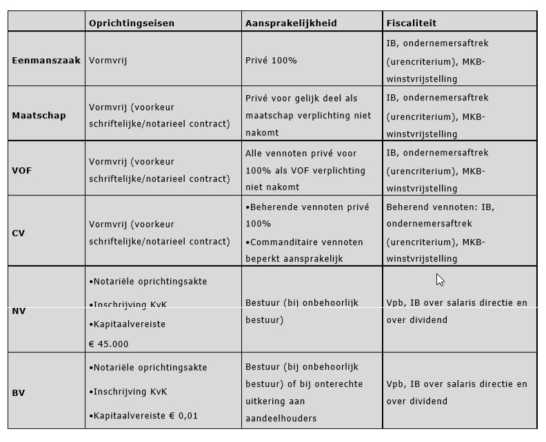

#### 12.3 De Oudedagsreserve

Is een alternatief voor vrijwillige pensioensverzekering en een aanvulling voor verplichte bedrijfs- of beroepspensioenregelingen. Dit heet de oudedagsreserve. Deze kan opgebouwd worden door een IB-ondernemer die:

- aan het begin van het kalenderjaar nog geen AOW-leeftijd heeft.
- voldoet aan het urencriterium
- de stand van de oudedagsreserve is lager dan het ondernemingsverogen op de balans.

De berekening van de dotatie op de OR is als volgt:

1. Stap 1 = *berekenen van de winst*
   - is de nettowinst van de ondernemer voor aftrek van de ondernemersaftrek, MKB-winstvrijstelling en verplichte deelname pensioenregeling.
2. Stap 2 = *berekenen van het maximale dotatiepercentage*
   - dit jaar mag er maximaal 9.8% van de winst worden gedoteerd aan de OR
3. Stap 3 = *rekening houden met het vaste plafond*
   - dit jaar staat dit op max EUR 8.500
4. Stap 4 = *maximering op het verschil tussen ondernemingsvermogen en stand OR*
   - de dotatie is gemaximeerd op het bedrag waarmee het ondernemingsvermogen bij het einde van het kalenderjaar de OR bij het begin van het kalenderjaar te boven gaat.
5. Stap 5 = *berekening van de dotatie*
   - indien er wordt gekozen voor dotatie, moet het maximale bedrag gedoteerd worden.
   - de opbouw is per ondernemer.
     - indien de ondernemer meerdere ondernemingen heeft, dan moet de winst van alle ondernemingen bij elkaar worden opgeteld.
     - als een onderneming meerdere ondernemers heeft, dan moet de winst eerst onderling verdeeld te worden.

De OR neemt in de volgende gevallen verplicht af:

- afneming van de OR met een bedrag naar keuze van de belastingplichtige.
- afneming met het bedrag waarmee de reserve het vermoge aan het einde van het kalenderjaar overtreft:
  - indien in het kalenderjaar de onderneming is gestaakt.
  - de belastingplichtige heeft de AOW-leeftijd bereitk.
  - de belastingplichtige heeft in het kalenderjaar, en het voorgaande jaar niet aan het urencriterium voldaan.
- het afgenomen bedrag gestort wordt in een lijfrente is er geen belasting in Box 1 verschuldigd.
- in het geval van verlies hoeft de ondernemer de reserve niet op te heffen als het vermogen beneden de reserve daalt. Er mogen echter dan geen dotaties meer worden gedaan.

Wanneer de OR expireert:

- er kan een oudedagslijfrente bij een professionele verzekeraar worden bedingd.
  - dit kan ook in verschillene lijfrenten.
- bij het overlijden van de ondernemer wordt de OR tegen het progressieve tarief in de winst opgenomen.
  - als de partner de onderneming rechtstreeks voortzet, kan schriftelijk worden verzocht dat de OR niet wordt opgeheven.
  - als één of meerdere erfgenamen een onmiddelijk ingaande lijfrente bedingen, kan ook heffing worden voorkomen. Het gaat dan om een nabestaandenlijfrente.

#### 12.4 De Stakingslijfrente.

In het geval van het stoppen met drijven van de onderneming, moet de ex-ondernemer over de zogenoemde stakingswinst inkomstenbelasting betalen.

In de volgende gevallen is er sprake van staking van een onderneming:

- de ondernemer verkoopt de onderneming; ook als de onderneming wordt omgezet in een BV.
- bij liquidatie van de onderneming
- bij overlijden van de ondernemer, en de partner of erfgename zetten de onderneming niet voort.

De stakingswinst wordt belast in box 1 en bestaat uit de volgende componenten:

- Goodwill = de meerwaarde van een onderneming door een trouwe klantenkring.
- stille reserves = het meerdere boven de boekwaarden van de activa en passiva.
- fiscale reserves = egalisatiereserve, herinvesteringsreserve en de oudedagsreserve.

Binnen de maxima is het mogelijk om stakingswinst belastingvrij om te zetten in de stakingslijfrente. De premie van deze lijfrente is aftrekbaar, waarbij de hoogte afhankelijk is van de leeftijd en situatie van de ondernemer. Deze is maximaal EUR 450.000 en kan in de volgende gevallen van worden gebruik gemaakt:

- de ondernemer is niet ouder dan 5 jaar over de AOW-leeftijd.
- op het moment van staken is de ondernemer voor 45% of meer arbeidsongeschikt en de termijnen gaan binnen 6 maanden in.
- de onderneming wordt gestaakt door overlijden van de ondernemer.

In de volgende gevallen kan een aftrek van maximaal EUR 225.000 gebruik worden gemaakt:

- de ondernemer is op het moment van staken niet ouder dan 15 jaar over de AOW-leeftijd.
- de lijfrente termijnen gaan direct in.

In alle overige gevallen is de aftrek maximaal EUR 115.000. Al deze vrijstellingen zijn life time-vrijstellingen.

Op bovengenoemde maxima komen de volgende voorzieningen in mindering:

- de waarde van de aanspraken die berusten op de pensioenregeling die de ondernemer heeft opgebouwd tijdens zijn ondernemerschap.
- het bedrag van de OR bij het begin van het kalenderjaar.
- de eerder afgetrokken lijfrentepremies op basis van jaar- en reserveringsruimte.
- eerder in aftrek gebrachte premies in verband met staking.

Bij het overtreden van de fiscale voorwaarden zijn dezelfde sancties van toepassing als op normale lijfrentes.

## 13 De DGA en de oude dag

*(pg 175-184)*

De `DGA` heeft andere mogelijkheden voor het opbouwen van pensioen, namelijk pensioen in eigen beheer opbouwen.

#### 13.1 Wie is de DGA?

De DGA is een werknemer die meer dan 10% van de aandelen in de BV bezit, en staat ingeschreven als eigenaar in het aandeelhoudersregister. De onderbrengingsplicht, namelijk dat de werkgever verplicht is een pensioen bij een professioneel fonds onder te brengen, geld niet voor een DGA

#### 13.2 Pensioen in eigen beheer versus verzekeren.

De DGA heeft de keuze:

- Pensioen verzekeren.
- Pensioen opbouwen in eigen beheer.

#### 13.3 Liquiditeit

Het pensioengeld word niet weggebracht naar een verzekering, maar binnen de eigen onderneming gehouden. Dit bedrag wordt dan op de balans geplaatst. Dit staat dan onder de zgn. eigenbeheerreserve of pensioenverplichting. Het jaarlijkse bedrag dat hier aan wordt toegevoegd is de pensioendotatie. Deze dotatie kan in mindering worden gebracht op de winst, waardoor vennootschapsbelastig kan worden bespaart.  
Hoewel dit geld is gereserveerd voor het pensioen, is de DGA niet verplicht het hiervoor te behouden. Door het geld in eigen beheer te houden, ontstaat er liquiditeitsverruiming. Nadeel hiervan is dat dit geld er dan niet meer is op het moment dat de DGA met pensioen gaat, anders gelden er fiscale consequenties en geen geld om pensioen mee aan te kopen.

## 14 Balanslezen

*(pg 185-193)*

De balans is een momentopname van de financiële positie van een onderneming. Om te kijken hoe een onderneming binnen een bepaalde tijd heeft gepresteerd, kan er gekeken worden naar de resultatenrekening, of winst-en-verliesrekening.

#### 14.1 Balans

De posten kunnen worden onderverdeeld in:

- Bezittingen
- Schulden
- Eigen vermogen (bezittingen minus schulden)

De bezittingen of activa staan links op de balans, op de debetzijde, de schulden en het eigen vermogen of pasiva, staan rechts op de balans, op de creditzijde.

- *De Activa*
  - Vaste activa:
    - Immateriële vaste activa.
      - Goodwill, d.w.z. wat een koper bereid is te betalen boven de intrinsieke waarde van de onderneming.
      - kosten in verband met oprichting en uitgifte van aandelen
      - kosten van onderzoek en ontwikkeling
      - kosten van verwerving voor concessies, vergunningen en rechten van intellectuele eigendom.
      - kosten van goodwill die van derden is verkregen.
      - vooruitbetaling op immateriële vaste activa.
    - Materiële vaste activa.
      - bedrijfgebouwen en -terreinen
      - machines en installaties
      - andere vaste bedrijfsmiddelen materiële vaste activa in uitvoering en vooruitbetalingen op materiële vaste activa.
      - niet aan het productieproces dienstbare materiële vaste activa.
    - Materiële vaste activa nemen af in waarde. Dit word op de balans verwoord door middel van afschrijvingen.
    - Financiële vaste activa.
      - deelnemingen in en vorderingen op groepsmaatschappijen.
  - Vlottende activa.
    - Voorraden
      - grond- en hulpstoffen
      - onderhanden werk
      - gereed product en handelsgoederen
      - vooruitbetaling op voorraden.
    - Vorderingen
      - vorderingen op handelsdebiteuren.
    - Effecten.
    - Liquide middelen.
      - kasmiddelen
      - tegoeden op bank-en girorekeningen
      - wissels en cheques.
- *De Passiva*
  - Het eigen vermogen:
    - het geplaatste kapitaal
    - agio
    - herwaarderingsreserves
    - andere wettelijke reserves, onderscheidend naar hun aard
    - statutaire reserves
    - overige reserves
    - niet verdeelde winsten, met aparte vermelding van het resultaat na belastingen.
  - Voorzieningen.
    - ter dekking van toekomstige uitgaven.
    - de ondernemer is niet vrij in elke situatie te vormen.
    - Zijn geen eigen vermogen, maar vreemd vermogen.
  - Schulden.
    - Schulden die apart vernoemd dienen te worden zijn:
      - obligatieleningen, pandbrieven en andere leningen met afzonderlijke vermelding an converteerbare leningen.
      - schulden aan kredietinstellingen
      - schulden aan leveranciers en handelskredieten.
      - schulden ter zake van belastingen en premies van sociale verzekeringen.
    - Er kan een onderscheid worden gemaakt tussen lange en korte termijn schulden.
      - Meestal gesteld op 1 jaar.

#### 14.2 Winst-en-verliesrekening

Het winstsaldo wordt bepaald door het verschil van de opbrengsten en de kosten. Bij winst staat het saldo aan de kant van de kosten, bij verlies staat het bij de opbrengsten.

Zaken die aan de kostenkant van de winst-en-verliesrekning komen te staan zijn:

- Loonkosten
- vaste afschrijvingskosten
- huurkosten
- rente over schulden
- kleine kostenposten:
  - telefonie
  - elektriciteit
  - etc.
- incidentele lasten

Opbrengsten:

- verkoopobrengst
- rentebaten
- incidentele baten

Met een vermogensvergelijking is het ook mogelijk om de winst in een bepaald jaar te bepalen. Hier wordt de balans aan het einde van het jaar vergeleken met de balans aan het begin van het jaar. Zaken die bij deze berekening ook van belang zijn, zijn eventuele stortingen en onttrekkingen aan het eigen vermogen.

Liquiditeit & solvabiliteit.

- Liquiditeit:
  - de mate waarin de onderneming in staat is om aan haar directe opeisbare verplichtingen te voldoen.
- Solvabiliteit:
  - de mate waarin de onderneming in staat is om aan AL haar verplichtingen te kunnen doen, zowel korte als lange termijn.

## 15 De macro-economische omgeving

*(pg 195-201)*

Allerlei zaken die van invloed zijn op het beleggersklimaat.

#### 15.1 De economische kringloop; de betrokken partijen in de macro-economie

De financiële markt is de plaats waar het aanbod en de vrraag naar financiële middelen elkaar ontmoeten.

- Partijen willen uitgaven doen waar ze nog niet de middelen over beschikken (financieringstekort).
  - lenen op de markt.
- Partijen met geld over, en de wens tot sparen (financieringsoverschot).
  - beleggen op de markt.
- Financiële instellingen.
  - faciliteren de overdracht.

De vraag en aanbod op de kapitaalmarkt bepaald de marktrente.

#### 15.2 Wat is macro-economie.

Macro-economie houdt zich bezig met de bestudering van economische systemen als geheel. Hier wordt geen onderscheid gemaakt tussen de afzonderlijke producten of diensten.

Er wordt onderscheid gemaakt in economische sectoren:

- consumenten
  - Neemt de belangrijkste plaats in.
  - brengt het grootste deel van het BNP voort.
  - laat zich leiden door toekomstverwachtingen.
- producenten
  - het bedrijfsleven.
  - probeert in de behoeften van de consumenten te voorzien.
  - doelen zijn vaak maximale winst, of groot marktaandeel hebben.
  - proberen deze doelstellingen te verwezelijken door het ontwikkelen van producten.
- overheid
  - vervult zowel een rol als consument als producent.
  - financiëert projecten door middel van belasting en vermogenstitels.
- buitenland
  - Ieder land handeld in meer of mindere mate met andere landen.
  - grote interne markten zijn onafhankelijker
  - kleinere landen doorgaans afhankelijk van import en export.
  - landen kunnen zich specialiseren om concurrentievoordeel te behalen.
- centrale bank
  - voert beleid met aanzien van de wisselkoers.
  - met rente probeert de centrale bank deze te sturen.
  - dit heeft invloed ophet gedrag van consumenten en producenten.

#### 15.3 Indicatoren voor beleggingsbeslissingen

Binnen deze context is een indicator een getal dat een betrouwbare aanwijzing is voor de waarde van iets. Beleggers laten zich door deze indicatoren leiden in hun beleggingsbeslissingen.

Voorbeelden van indicatoren:

1. economische groei.
   - veranderingnen van economische activiteit gemeten door vergelijking met een eerder meetpunt.
   - schommelingen heten hier conjunctuur.
     - hoogconjunctuur = sterke groei
     - laagconjunctuur = trage groei
     - crisis = negatieve groei
2. inflatie
   - het verschijnsel dat geld steeds minder waard wordt.
   - inflatie en deflatie is in te hoge mate dramatisch voor de economie.
   - voor het gelijkblijven van de koopkracht is het belangrijk dat de lonen stijgen met de inflatie.
   - monetaire geldhoeveelheid is de hoeveelheid geld die de centrale bank in omloop heeft gebracht.
   - omloopsnelheid is het aantal keren dat het geld in een jaar wordt uitgegeven.
   - manieren van inflatiebestrijding zijn:
     - bij monetaire inflatie kan de geldhoeveelheid worden beperkt.
     - bij bestedingsinflatie kan een restrictief monetair beleid worden gehandhaaft. d.w.z. rente verhogen om het duurder te maken om geld te lenen.
     - bij kosteninflatie is het erg lastig te bestrijden omdat de prijs van grondstoffen wordt bepaald door de wereldmarkt.
     - bij looninflatie is goed overleg tussen werkgevers en werknemers het belangijkst.
     - bij deflatie dalen de prijzen van goederen structureel.
       - beperkt vertrouwen van de consument.
       - consumenten stellen bestedingen uit in verwachting van verdere prijsdalingen.
       - de overheid kan dit beperken door stimuleringsmaatregelen in te voeren.
   - de overheid kan de economie sturen door budgettair beleid.
   - de centrale bank kan de economie sturen door renteinstrument.
3. Rente.
   - geldmarkt
     - hier worden geldmiddelen verhandeld met een looptijd van minder dan een jaar.
     - de rente op deze markt wordt grotendeels bepaald door de Europese Centrale Bank.
     - deze rente is lager dan de rente van banken onderling, dus dat stimuleert banken te lenen bij de centrale bank.
       - de verwachting is dat veranderingen op deze rente doorgerekend worden naar de klanten van de banken.
     - ook vraag en aanbod van leningen bepalen de hoogte van de rente.
       - bij een stijgende vraag naar leningen bij een lager aanbod zal de rente stijgen.
       - omgekeerd zal het dalen.
   - kapitaalmarkt
     - hier worden geldmiddelen met een middellange of lange looptijd verhandeld.
     - kasoverschotten of kastekorten zijn hiervan van invloed op de ontwikkeling van de rente.
     - inflatie speelt ook hier een grote rol.
   - Beleggingsbeslissingen.
     - manieren om middelenoverschotten te investeren:
       - financiële titels:
         - aandelen
         - obligaties
         - spaarrekeningen.
     - voor elke soort financiële titel een eigen makrt met een eigen prijs.
       - de hoogte van de rentevoet is de vergoeding voor het ter beschikking stellen van de middelen op de markt.
     - verschillen onderling in looptijd, risico, en soort geldvrager.

## 16 Wetgeving en zorgplicht

*(pg 203-221)*

## 17 Het klantprofiel

*(pg 223-239)*

## 18 Beleggingscategorieën

*(pg 241-255)*

## 19 Beleggingsfondsen

*(pg 257-268)*

## 20 Risico en Rendement

*(pg 269-276)*

## 21 Beheer en mutatie van beleggingsportefeuilles

*(pg 279-283)*

## 22 Professioneel gedrag

*(pg 285-311)*

## 23 Integriteit

*(pg 313-335)*

## 24 Adviesvaardigheden

*(pg 337-357)*

## Appendix

#### Afkortingen

- Anw = Algemene Nabestaande Wet
- AOW = Algemene Ouderdoms Wet
- BEW = Beleggersrecht Eigen Woning
- BV = Besloten Vennootschap
- DGA = Directeur Groot-Aandeelhouder
- KEW = Kapitaalverzekering Eigen Woning
- ORV = Overlijdensrisicoverzekering
- PW = Pensioen Wet
- SEW = Spaarrekening Eigen Woning
- UPO = Uniform Pensioenoverzicht
- WIA = Wet werk en inkomen naar arbeidsvermogen
- Wlz = Wet Langdurige Zorg
- WMK = Wet Medische Keuring
- WGBO = Wet op de Geneeskundige Behandelingsovereenkomst
- Wvb = Wet verplichte beroepsregeling
- Wet VPL = Wet aanpassing fiscale behandeling VUT, prepensioen en introductie levensloop
- WOZ = Wet waardering onroerende zaken
- WVPS = Wet Verevening Pensioenrechten bij Scheiding
- WW = Werkloosheids Wet